# Mapping IRAK4, PUS7L, and ANRIL expression in atherosclerotic plaques.

A ‘druggable-MI-targets’ project

[Sander W. van der Laan, PhD](https://swvanderlaan.github.io) | @swvanderlaan; Alejandro Lopez-Rincon, PhD

2020-08-07

# 1 General Setup

First we will create the proper environment and set some general parameters and folders for the project.

* Clean the environment.

* Set locations, and the working directory …

```
Defining phenotypes and datasets.

Create a new analysis directory, including subdirectories.
[1] TRUE
[1] TRUE
[1] TRUE
[1] TRUE
[1] TRUE

Setting working directory and listing its contents.
[1] "/Users/swvanderlaan/PLINK/analyses/lookups/AE_171212_GBASATEMUR_ZMALLAT/multiAssay"
[1] "AECPGRNA"           "multiAssay.nb.html" "multiAssay.Rmd"     "Untitled.nb.html"   "Untitled.Rmd"
```

* A package-installation function.

*Load those packages.*

```
* General packages...

* Genomic packages...

* DNAmArray package...

* MultiAssayExperiment package...
```

We will also create a datestamp and define the Utrecht Science Park Colour Scheme.

# 2 Executive summary

## 2.1 ERA-CVD ‘druggable-MI-targets’

Plaque samples are derived from carotid endarterectomies as part of the Athero-Express Biobank Study which is an ongoing study in the UMC Utrecht.

## 2.2 Background

In the past decade genome-wide association studies (GWAS) have robustly linked common genetic variation to *coronary artery disease (CAD)*, and identified three genes, *IRAK4, PUS7L, and ANRIL* potentially causally involved in CAD risk. These genes are given in a list below.

- *IRAK4*
- *PUS7L*
- *ANRIL* a.k.a. *CDKN2B-AS1*

Here we will analyze the association between DNAm at specific CpGs with the gene expression of *IRAK4, PUS7L, and ANRIL*.

We will construct a list of genes to map.

```r
target_genes <- unlist(c("IRAK4", "PUS7L", "CDKN2B-AS1"))

target_genes
```

```
[1] "IRAK4"      "PUS7L"      "CDKN2B-AS1"
```

# 3 Athero-Express Biobank Study

The *[Athero-Express Biobank Study (AE)](http://www.atheroexpress.nl)* contains plaque material of patients that underwent endarterectomyat two Dutch tertiary referral centers. Details of the study design were described before. Briefly, blood and plaque material were obtained during endarterectomy and stored at -80 ℃. Only carotid endarterectomy (CEA) patients were included in the present study. All patients provided informed consent and the study was approved by the medical ethics committee.

## 3.1 Athero-Express Methylation Study

We study genome-wide *DNA methylation* (DNAm) in carotid atherosclerotic plaques using data from the [Athero-Express Biobank Study](http://www.atheroexpress.nl). Previously we published an *Epigenome-Wide Association Study* (EWAS) [on tobacco smoking](https://www.ahajournals.org/doi/10.1161/CIRCGEN.117.002030) based on plaque-derived DNAm as measured using the [Illumina Human Methylation 450K BeadArray](https://www.ncbi.nlm.nih.gov/pubmed/22126295).

We used the [DNAmArray libary](https://github.com/molepi/DNAmArray) and associated [Workflow](https://molepi.github.io/DNAmArray_workflow/index.html) for quality control and normalization of the DNAm data.

Recently, there was an update of the list of problematic probes[^1]. Three groups of probes should generally be filtered out from Infinium microarray analyses:

1. probes with internal SNPs close to the 3΄ end of the probe (*Group 1*);
2. probes with non-unique mapping to the bisulfite-converted genome (*Group 2*); and
3. probes with off-target hybridization due to partial overlap with non-unique elements (*Group 3*).

More information can be found here: http://zwdzwd.github.io/InfiniumAnnotation#current.

There is also another list, which is partly overlapping with Zhou’s, created by Naeem et al.[^2]

Two sets of samples were randomly selected from the Athero-Express Biobank Study:

- Athero-Express Methylation Study 1 (AEMS450K1)
- Athero-Express Methylation Study 2 (AEMS450K2)

## 3.2 Athero-Express RNAseq Study

The bulk RNAseq data are filtered and corrected:

- UMI corrected
- unmappable genes are excluded

The bulk RNAseq samples were selected such to provide maximal overlap with the AEMS450K and AEGS data, overlapping about 90-95%[^3].

# 4 Load data

We will load the data:

- Athero-Express clinical data.
- the AERNA data.
- the AEMS450K1 and AEMS450K2 data.

## 4.1 Clinical Data

Loading Athero-Express Biobank Study clinical and biobank data, as well as the SampleList of genetic data.

```r
cat("Loading Athero-Express Biobank Study Database...")
```

```
Loading Athero-Express Biobank Study Database...
```

```r
# METHOD 1: It seems this method gives loads of errors and warnings, which all are hard to comprehend
#           or debug. We expect 3,527 samples, and 927 variables; we get 927 variables!!!
# AEdata = as.data.table(read.spss(paste0(INP_loc,"/2017-1NEW_AtheroExpressDatabase_ScientificAE_20171306_v1.0.sav"),
#                                  trim.factor.names = TRUE, trim_values = TRUE, # we trim spaces in values
#                                  reencode = TRUE, # we re-encode to the local locale encoding
#                                  add.undeclared.levels = "append", # we do *not* want to convert to R-factors
#                                  use.value.labels = FALSE, # we do *not* convert variables with value labels into R factors
#                                  use.missings = TRUE, sub = "NA", # we will set every missing variable to NA
#                                  duplicated.value.labels = "condense", # we will condense duplicated value labels
#                                  to.data.frame = TRUE))
# AEdata.labels <- as.data.table(attr(AEdata, "variable.labels"))
# names(AEdata.labels) <- "Variable"

# METHOD 2: Using library("haven") importing seems flawless; best argument being:
#           we expect 3,527 samples and 888 variables, which is what you'd get with this method
#           So for now, METHOD 2 is prefered.
#
require(haven)

# AEDB <- haven::read_sav(paste0(AEDB_loc, "/2019-3NEW_AtheroExpressDatabase_ScientificAE_02072019_IC_added.sav"))
AEDB <- haven::read_sav(paste0(AEDB_loc, "/2020_1_NEW_AtheroExpressDatabase_ScientificAE_16-03-2020.sav"))

# writing off the SPSS data to an Excel.
# fwrite(AEdata, file = paste0(INP_loc,"/2017-1NEW_AtheroExpressDatabase_ScientificAE_20171306_v1.0.values.xlsx"),
#        sep = ";", na = "NA", dec = ".", col.names = TRUE, row.names = FALSE,
#        dateTimeAs = "ISO", showProgress = TRUE, verbose = TRUE)
# warnings()

AEDB[1:10, 1:10]
```

| STUDY_NUMBER | UPID | AE_AAA_bijzonderheden | informedconsent | writtenIC | EZis | date_ic_patient | date_ic_researcher | Hospital | Gender |
| --- | --- | --- | --- | --- | --- | --- | --- | --- | --- |
| 3 | UPID01241 | NA | 1 | 1 | NA | 2002-03-25 | 2002-04-21 | 1 | 1 |
| 7 | UPID01636 | NA | 1 | 1 | NA | 2002-03-23 | 2002-03-28 | 1 | 1 |
| 9 | UPID00918 | NA | 1 | 1 | NA | 2002-03-21 | 2002-04-22 | 1 | 1 |
| 10 | UPID01934 | NA | 30 | 0 | NA |  |  | 1 | 1 |
| 12 | UPID00169 | NA | 1 | 1 | NA | 2002-04-16 | 2002-04-16 | 1 | 1 |
| 13 | UPID00678 | NA | 1 | 1 | NA | 2002-04-16 | 2002-04-16 | 1 | 0 |
| 14 | UPID00365 | NA | 1 | 1 | NA | 2002-04-26 | 2002-04-26 | 1 | 0 |
| 15 | UPID01701 | NA | 1 | 1 | NA | 2002-06-13 | 2002-06-13 | 1 | 1 |
| 17 | UPID00846 | NA | 0 | 0 | NA |  |  | 1 | 0 |
| 18 | UPID01766 | NA | 1 | 1 | NA | 2002-05-27 | 2002-05-27 | 1 | 0 |

```r
dim(AEDB)
```

```
[1] 3791 1091
```

```r
cat("* load in the Athero-Express (i.e. EDTA, plaque, protein) biobank data.")
```

```
* load in the Athero-Express (i.e. EDTA, plaque, protein) biobank data.
```

```r
require(openxlsx)
AEDB_ProtConc <- openxlsx::read.xlsx(paste0(AEDB_loc, "/_Vriezer/20190919_Freezers_preTCBio.xlsx"),
                                     sheet = "ProteinConc.",
                                     skipEmptyCols = TRUE)

AEDB_Blood <- openxlsx::read.xlsx(paste0(AEDB_loc, "/_Vriezer/20190919_Freezers_preTCBio.xlsx"),
                                     sheet = "Blood",
                                     skipEmptyCols = TRUE)
AEDB_Plaque <- openxlsx::read.xlsx(paste0(AEDB_loc, "/_Vriezer/20190919_Freezers_preTCBio.xlsx"),
                                     sheet = "Plaque",
                                     skipEmptyCols = TRUE)

head(AEDB_ProtConc)
```

```
'head' showing 6 out of 33 columns!
```

|  | STUDY_NUMBER | AE_# | BoxTPUMCU | LocationTPUMCU | PresTubeA_TPUMCU | PresTubeB_TPUMCU |
| --- | --- | --- | --- | --- | --- | --- |
| 1 | 1 | 1 | 1 | A1-A4 | 1 | 1 |
| 2 | 2 | 2 | 1 | A5-A8 | 1 | 1 |
| 3 | 3 | 3 | 1 | A9-B2 | 1 | 1 |
| 4 | 4 | 4 | 1 | B3-B6 | 1 | 1 |
| 5 | 5 | 5 | 1 | B7-B10 | 1 | 1 |
| 6 | 6 | 6 | 1 | C1-C4 | 1 | 0 |

```r
head(AEDB_Blood)
```

```
'head' showing 6 out of 22 columns!
```

|  | STUDY_NUMBER | Code.sample | Responsible.(CO) | Division.(auto.fill.) | Department.(auto.fill.) | PI./.contactperson |
| --- | --- | --- | --- | --- | --- | --- |
| 1 | 1 | AE 1_HEP 3 | Pasterkamp. G. | DLA | LKCH | Schoneveld, A.H. |
| 2 | 1 | AE 1_Cit 1 | Pasterkamp. G. | DLA | LKCH | Schoneveld, A.H. |
| 3 | 1 | AE 1_Cit 2 | Pasterkamp. G. | DLA | LKCH | Schoneveld, A.H. |
| 4 | 1 | AE 1_EDTA 3 | Pasterkamp. G. | DLA | LKCH | Schoneveld, A.H. |
| 5 | 1 | AE 1_serum 2 | Pasterkamp. G. | DLA | LKCH | Schoneveld, A.H. |
| 6 | 1 | AE 1_serum 3 | Pasterkamp. G. | DLA | LKCH | Schoneveld, A.H. |

```r
head(AEDB_Plaque)
```

```
'head' showing 6 out of 19 columns!
```

|  | STUDY_NUMBER | Code.sample | Responsible.(CO) | Division.(auto.fill.) | Department.(auto.fill.) | PI./.contactperson |
| --- | --- | --- | --- | --- | --- | --- |
| 1 | 11 | AE 11 | Pasterkamp, G. | DLAB | LKCH | Schoneveld, A.H. |
| 2 | 11 | AE 11 | Pasterkamp, G. | DLAB | LKCH | Schoneveld, A.H. |
| 3 | 11 | AE 11 | Pasterkamp, G. | DLAB | LKCH | Schoneveld, A.H. |
| 4 | 11 | AE 11 | Pasterkamp, G. | DLAB | LKCH | Schoneveld, A.H. |
| 5 | 14 | AE 14 | Pasterkamp, G. | DLAB | LKCH | Schoneveld, A.H. |
| 6 | 14 | AE 14 | Pasterkamp, G. | DLAB | LKCH | Schoneveld, A.H. |

```r
cat("* get list of UPIDs-studynumber to Zipcode/City mapping")
```

```
* get list of UPIDs-studynumber to Zipcode/City mapping
```

```r
UPID_ZIPcodes = as.data.table(read.xlsx(paste0(AEDB_loc,"/20170821_UPID_ZIPcodes_basedon_20141208.xlsx"),
                                      sheet = 1, colNames = TRUE, rowNames = TRUE, detectDates = TRUE,
                                      skipEmptyRows = TRUE, skipEmptyCols = TRUE, na.strings = c("NA", ".", "")))
dim(UPID_ZIPcodes)
```

```
[1] 6123    5
```

```r
names(UPID_ZIPcodes)[names(UPID_ZIPcodes) == "STUDY_STYPE"] <- "STUDY_TYPE"
UPID_ZIPcodes[1:10, 1:5]
```

| STUDY_NUMBER | UPID | STUDY_TYPE | Postcode | Plaats |
| --- | --- | --- | --- | --- |
| 1839 | UPID02597 | AE | 3522 GS | Utrecht |
| 4140 | UPID04204 | AE | NA | NA |
| 4147 | NA | AE | NA | NA |
| 4148 | NA | AE | NA | NA |
| 1730 | UPID01434 | AE | 3562 EG | Utrecht |
| 1761 | UPID01877 | AE | 4335 PL | Middelburg |
| 2406 | UPID02562 | AE | 4001 HP | Tiel |
| 2459 | UPID02802 | AE | 4131 ZS | Vianen |
| 2515 | UPID03155 | AE | 3531 SH | Utrecht |
| 2606 | UPID02605 | AE | 2064 WS | Spaarndam |

```r
cat("* get Athero-Express Genomics Study keys...")
```

```
* get Athero-Express Genomics Study keys...
```

```r
AEGS123.sampleList.keytable <- fread(paste0(AEGSQC_loc, "/QC/SELECTIONS/20200319.QC.AEGS123.sampleList.keytable.txt"))

dim(AEGS123.sampleList.keytable)
```

```
[1] 2124   25
```

```r
# AEGS123.sampleList.keytable[1:10, 1:10]
```

### 4.1.1 Examine AEDB

We can examine the contents of the Athero-Express Biobank dataset to know what each variable is called, what class (type) it has, and what the variable description is.

There is an excellent post on this: https://www.r-bloggers.com/working-with-spss-labels-in-r/.

```r
AEDB %>% sjPlot::view_df(show.type = TRUE,
                         show.frq = TRUE,
                         show.prc = TRUE,
                         show.na = TRUE,
                         max.len = TRUE,
                         wrap.labels = 20,
                         verbose = FALSE,
                         use.viewer = FALSE,
                         file = paste0(OUT_loc, "/", Today, ".AEDB.dictionary.html"))
```

### 4.1.2 Fix clinical data

We need to be very strict in defining *symptoms.* Therefore we will fix a new variable that groups *symptoms* at inclusion.

Coding of *symptoms* is as follows:

- missing -999
- Asymptomatic 0
- TIA 1
- minor stroke 2
- Major stroke 3
- Amaurosis fugax 4
- Four vessel disease 5
- Vertebrobasilary TIA 7
- Retinal infarction 8
- Symptomatic, but aspecific symtoms 9
- Contralateral symptomatic occlusion 10
- retinal infarction 11
- armclaudication due to occlusion subclavian artery, CEA needed for bypass 12
- retinal infarction + TIAs 13
- Ocular ischemic syndrome 14
- ischemisch glaucoom 15
- subclavian steal syndrome 16
- TGA 17

We will group as follows:

1. Asymptomatic > 0
2. TIA > 1, 7, 13
3. Stroke > 2, 3
4. Ocular > 4, 14, 15
5. Retinal infarction > 8, 11
6. Other > 5, 9, 10, 12, 16, 17

```r
# Fix symptoms

attach(AEDB)
AEDB[,"Symptoms.5G"] <- NA
AEDB$Symptoms.5G[sympt == 0] <- "Asymptomatic"
AEDB$Symptoms.5G[sympt == 1 | sympt == 7 | sympt == 13] <- "TIA"
AEDB$Symptoms.5G[sympt == 2 | sympt == 3] <- "Stroke"
AEDB$Symptoms.5G[sympt == 4 | sympt == 14 | sympt == 15 ] <- "Ocular"
AEDB$Symptoms.5G[sympt == 8 | sympt == 11] <- "Retinal infarction"
AEDB$Symptoms.5G[sympt == 5 | sympt == 9 | sympt == 10 | sympt == 12 | sympt == 16 | sympt == 17] <- "Other"


# AsymptSympt
AEDB[,"AsymptSympt"] <- NA
AEDB$AsymptSympt[sympt == -999] <- NA
AEDB$AsymptSympt[sympt == 0] <- "Asymptomatic"
AEDB$AsymptSympt[sympt == 1 | sympt == 7 | sympt == 13 | sympt == 2 | sympt == 3] <- "Symptomatic"
AEDB$AsymptSympt[sympt == 4 | sympt == 14 | sympt == 15 | sympt == 8 | sympt == 11 | sympt == 5 | sympt == 9 | sympt == 10 | sympt == 12 | sympt == 16 | sympt == 17] <- "Ocular and others"

# AsymptSympt
AEDB[,"AsymptSympt2G"] <- NA
AEDB$AsymptSympt2G[sympt == -999] <- NA
AEDB$AsymptSympt2G[sympt == 0] <- "Asymptomatic"
AEDB$AsymptSympt2G[sympt == 1 | sympt == 7 | sympt == 13 | sympt == 2 | sympt == 3 | sympt == 4 | sympt == 14 | sympt == 15 | sympt == 8 | sympt == 11 | sympt == 5 | sympt == 9 | sympt == 10 | sympt == 12 | sympt == 16 | sympt == 17] <- "Symptomatic"

detach(AEDB)

# table(AEDB$sympt, useNA = "ifany")
# table(AEDB$AsymptSympt2G, useNA = "ifany")
# table(AEDB$Symptoms.5G, useNA = "ifany")
#
# table(AEDB$AsymptSympt2G, AEDB$sympt, useNA = "ifany")
# table(AEDB$Symptoms.5G, AEDB$sympt, useNA = "ifany")
table(AEDB$AsymptSympt2G, AEDB$Symptoms.5G, useNA = "ifany")
```

```
               Asymptomatic Ocular Other Retinal infarction Stroke  TIA <NA>
  Asymptomatic          333      0     0                  0      0    0    0
  Symptomatic             0    416   119                 43    732 1045    0
  <NA>                    0      0     0                  0      0    0 1103
```

```r
# AEDB.temp <- subset(AEDB,  select = c("STUDY_NUMBER", "UPID", "Age", "Gender", "Hospital", "Artery_summary", "sympt", "Symptoms.5G", "AsymptSympt"))
# require(labelled)
# AEDB.temp$Gender <- to_factor(AEDB.temp$Gender)
# AEDB.temp$Hospital <- to_factor(AEDB.temp$Hospital)
# AEDB.temp$Artery_summary <- to_factor(AEDB.temp$Artery_summary)
#
# DT::datatable(AEDB.temp[1:10,], caption = "Excerpt of the whole AEDB.", rownames = FALSE)
#
# table(AEDB.temp$Symptoms.5G, AEDB.temp$AsymptSympt)
#
# rm(AEDB.temp)
```

We will also fix the *plaquephenotypes* variable.

Coding of symptoms is as follows:

- missing -999
- not relevant -888
- fibrous 1
- fibroatheromatous 2
- atheromatous 3

```r
# Fix plaquephenotypes
attach(AEDB)
AEDB[,"OverallPlaquePhenotype"] <- NA
AEDB$OverallPlaquePhenotype[plaquephenotype == -888] <- NA
AEDB$OverallPlaquePhenotype[plaquephenotype == -999] <- NA
AEDB$OverallPlaquePhenotype[plaquephenotype == 1] <- "fibrous"
AEDB$OverallPlaquePhenotype[plaquephenotype == 2] <- "fibroatheromatous"
AEDB$OverallPlaquePhenotype[plaquephenotype == 3] <- "atheromatous"
detach(AEDB)

table(AEDB$OverallPlaquePhenotype, AEDB$plaquephenotype, useNA = "ifany")
```

```
                    -888    1    2    3 <NA>
  atheromatous         0    0    0  550    0
  fibroatheromatous    0    0  841    0    0
  fibrous              0 1439    0    0    0
  <NA>                52    0    0    0  909
```

```r
# AEDB.temp <- subset(AEDB,  select = c("STUDY_NUMBER", "UPID", "Age", "Gender", "Hospital", "Artery_summary", "plaquephenotype", "OverallPlaquePhenotype"))
# require(labelled)
# AEDB.temp$Gender <- to_factor(AEDB.temp$Gender)
# AEDB.temp$Hospital <- to_factor(AEDB.temp$Hospital)
# AEDB.temp$Artery_summary <- to_factor(AEDB.temp$Artery_summary)
#
# DT::datatable(AEDB.temp[1:10,], caption = "Excerpt of the whole AEDB.", rownames = FALSE)
#
# rm(AEDB.temp)
```

We will also fix the *diabetes* status variable.

```
There were 27 warnings (use warnings() to see them)
```

```r
# Fix diabetes
attach(AEDB)
AEDB[,"DiabetesStatus"] <- NA
AEDB$DiabetesStatus[DM.composite == -999] <- NA
AEDB$DiabetesStatus[DM.composite == 0] <- "Control (no Diabetes Dx/Med)"
AEDB$DiabetesStatus[DM.composite == 1] <- "Diabetes"
detach(AEDB)

table(AEDB$DiabetesStatus, AEDB$DM.composite, useNA = "ifany")
```

```
                                  0    1 <NA>
  Control (no Diabetes Dx/Med) 2764    0    0
  Diabetes                        0  985    0
  <NA>                            0    0   42
```

```r
# AEDB.temp <- subset(AEDB,  select = c("STUDY_NUMBER", "UPID", "Age", "Gender", "Hospital", "Artery_summary", "DM.composite", "DiabetesStatus"))
# require(labelled)
# AEDB.temp$Gender <- to_factor(AEDB.temp$Gender)
# AEDB.temp$Hospital <- to_factor(AEDB.temp$Hospital)
# AEDB.temp$Artery_summary <- to_factor(AEDB.temp$Artery_summary)
# AEDB.temp$DiabetesStatus <- to_factor(AEDB.temp$DiabetesStatus)
#
# DT::datatable(AEDB.temp[1:10,], caption = "Excerpt of the whole AEDB.", rownames = FALSE)
#
# rm(AEDB.temp)
```

We will also fix the *smoking* status variable. We are interested in whether someone never, ever or is currently (at the time of inclusion) smoking. This is based on the questionnaire.

- `diet801`: are you a smoker?
- `diet802`: did you smoke in the past?

We already have some variables indicating smoking status:

- `SmokingReported`: patient has reported to smoke.
- `SmokingYearOR`: smoking in the year of surgery?
- `SmokerCurrent`: currently smoking?

```r
require(labelled)
AEDB$diet801 <- to_factor(AEDB$diet801)
AEDB$diet802 <- to_factor(AEDB$diet802)
AEDB$diet805 <- to_factor(AEDB$diet805)
AEDB$SmokingReported <- to_factor(AEDB$SmokingReported)
AEDB$SmokerCurrent <- to_factor(AEDB$SmokerCurrent)
AEDB$SmokingYearOR <- to_factor(AEDB$SmokingYearOR)

# table(AEDB$diet801)
# table(AEDB$diet802)
# table(AEDB$SmokingReported)
# table(AEDB$SmokerCurrent)
# table(AEDB$SmokingYearOR)
# table(AEDB$SmokingReported, AEDB$SmokerCurrent, useNA = "ifany", dnn = c("Reported smoking", "Current smoker"))
#
# table(AEDB$diet801, AEDB$diet802, useNA = "ifany", dnn = c("Smoker", "Past smoker"))

cat("\nFixing smoking status.\n")
```

```
Fixing smoking status.
```

```r
attach(AEDB)
AEDB[,"SmokerStatus"] <- NA
AEDB$SmokerStatus[diet802 == "don't know"] <- "Never smoked"
AEDB$SmokerStatus[diet802 == "I still smoke"] <- "Current smoker"
AEDB$SmokerStatus[SmokerCurrent == "no" & diet802 == "no"] <- "Never smoked"
AEDB$SmokerStatus[SmokerCurrent == "no" & diet802 == "yes"] <- "Ex-smoker"
AEDB$SmokerStatus[SmokerCurrent == "yes"] <- "Current smoker"
AEDB$SmokerStatus[SmokerCurrent == "no data available/missing"] <- NA
# AEDB$SmokerStatus[is.na(SmokerCurrent)] <- "Never smoked"
detach(AEDB)

cat("\n* Current smoking status.\n")
```

```
* Current smoking status.
```

```r
table(AEDB$SmokerCurrent,
      useNA = "ifany",
      dnn = c("Current smoker"))
```

```
Current smoker
no data available/missing                        no                       yes                      <NA>
                        0                      2364                      1308                       119
```

```r
cat("\n* Updated smoking status.\n")
```

```
* Updated smoking status.
```

```r
table(AEDB$SmokerStatus,
      useNA = "ifany",
      dnn = c("Updated smoking status"))
```

```
Updated smoking status
Current smoker      Ex-smoker   Never smoked           <NA>
          1308           1814            389            280
```

```r
cat("\n* Comparing to 'SmokerCurrent'.\n")
```

```
* Comparing to 'SmokerCurrent'.
```

```r
table(AEDB$SmokerStatus, AEDB$SmokerCurrent,
      useNA = "ifany",
      dnn = c("Updated smoking status", "Current smoker"))
```

```
                      Current smoker
Updated smoking status no data available/missing   no  yes <NA>
        Current smoker                         0    0 1308    0
        Ex-smoker                              0 1814    0    0
        Never smoked                           0  389    0    0
        <NA>                                   0  161    0  119
```

```r
# AEDB.temp <- subset(AEDB,  select = c("STUDY_NUMBER", "UPID", "Age", "Gender", "Hospital", "Artery_summary", "DM.composite", "DiabetesStatus"))
# require(labelled)
# AEDB.temp$Gender <- to_factor(AEDB.temp$Gender)
# AEDB.temp$Hospital <- to_factor(AEDB.temp$Hospital)
# AEDB.temp$Artery_summary <- to_factor(AEDB.temp$Artery_summary)
# AEDB.temp$DiabetesStatus <- to_factor(AEDB.temp$DiabetesStatus)
#
# DT::datatable(AEDB.temp[1:10,], caption = "Excerpt of the whole AEDB.", rownames = FALSE)
#
# rm(AEDB.temp)
```

We will also fix the *alcohol* status variable.

```r
# Fix diabetes
attach(AEDB)
AEDB[,"AlcoholUse"] <- NA
AEDB$AlcoholUse[diet810 == -999] <- NA
AEDB$AlcoholUse[diet810 == 0] <- "No"
AEDB$AlcoholUse[diet810 == 1] <- "Yes"
detach(AEDB)

table(AEDB$AlcoholUse, useNA = "ifany")
```

```
  No  Yes <NA>
1238 2345  208
```

```r
# AEDB.temp <- subset(AEDB,  select = c("STUDY_NUMBER", "UPID", "Age", "Gender", "Hospital", "Artery_summary", "diet810", "AlcoholUse"))
# require(labelled)
# AEDB.temp$Gender <- to_factor(AEDB.temp$Gender)
# AEDB.temp$Hospital <- to_factor(AEDB.temp$Hospital)
# AEDB.temp$Artery_summary <- to_factor(AEDB.temp$Artery_summary)
# AEDB.temp$AlcoholUse <- to_factor(AEDB.temp$AlcoholUse)
#
# DT::datatable(AEDB.temp[1:10,], caption = "Excerpt of the whole AEDB.", rownames = FALSE)
#
# rm(AEDB.temp)
```

We will also fix and inverse-rank normal transform the continuous (manually) scored plaque phenotypes.

```r
AEDB$macmean0 <- as.numeric(AEDB$macmean0)
AEDB$smcmean0 <- as.numeric(AEDB$smcmean0)
AEDB$neutrophils <- as.numeric(AEDB$neutrophils)
AEDB$Mast_cells_plaque <- as.numeric(AEDB$Mast_cells_plaque)
AEDB$vessel_density_averaged <- as.numeric(AEDB$vessel_density_averaged)

AEDB$MAC_rankNorm <- qnorm((rank(AEDB$macmean0, na.last = "keep") - 0.5) / sum(!is.na(AEDB$macmean0)))
AEDB$SMC_rankNorm <- qnorm((rank(AEDB$smcmean0, na.last = "keep") - 0.5) / sum(!is.na(AEDB$smcmean0)))
AEDB$Neutrophils_rankNorm <- qnorm((rank(AEDB$neutrophils, na.last = "keep") - 0.5) / sum(!is.na(AEDB$neutrophils)))
AEDB$MastCells_rankNorm <- qnorm((rank(AEDB$Mast_cells_plaque, na.last = "keep") - 0.5) / sum(!is.na(AEDB$Mast_cells_plaque)))
AEDB$VesselDensity_rankNorm <- qnorm((rank(AEDB$vessel_density_averaged, na.last = "keep") - 0.5) / sum(!is.na(AEDB$vessel_density_averaged)))
```

```r
library(labelled)
AEDB$Gender <- to_factor(AEDB$Gender)
library(patchwork)
p1 <- ggpubr::gghistogram(AEDB, "macmean0",
                    # y = "..count..",
                    color = "white",
                    fill = "Gender",
                    palette = c("#1290D9", "#DB003F"),
                    add = "median",
                    #add_density = TRUE,
                    rug = TRUE,
                    #add.params =  list(color = "black", linetype = 2),
                    title = "% of macrophages (CD68)",
                    xlab = "% per region of interest",
                    ggtheme = theme_minimal())
```

```
Using `bins = 30` by default. Pick better value with the argument `bins`.
```

```r
p2 <- ggpubr::gghistogram(AEDB, "MAC_rankNorm",
                    # y = "..count..",
                    color = "white",
                    fill = "Gender",
                    palette = c("#1290D9", "#DB003F"),
                    add = "median",
                    #add_density = TRUE,
                    rug = TRUE,
                    #add.params =  list(color = "black", linetype = 2),
                    title = "% of macrophages (CD68)",
                   xlab = "% per region of interest\ninverse-rank normalized number",
                    ggtheme = theme_minimal())
```

```
Using `bins = 30` by default. Pick better value with the argument `bins`.
```

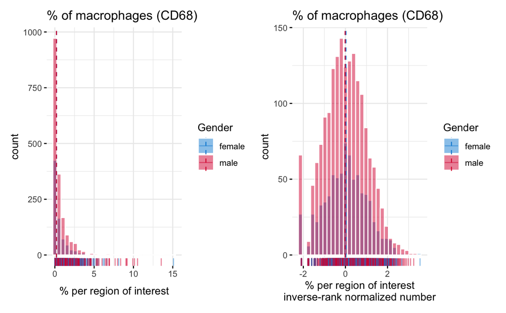

```r
p1 | p2
```

```r
p1 <- ggpubr::gghistogram(AEDB, "smcmean0",
                    # y = "..count..",
                    color = "white",
                    fill = "Gender",
                    palette = c("#1290D9", "#DB003F"),
                    add = "median",
                    #add_density = TRUE,
                    rug = TRUE,
                    #add.params =  list(color = "black", linetype = 2),
                    title = "% of smooth muscle cells (SMA)",
                    xlab = "% per region of interest",
                    ggtheme = theme_minimal())
```

```
Using `bins = 30` by default. Pick better value with the argument `bins`.
```

```r
p2 <- ggpubr::gghistogram(AEDB, "SMC_rankNorm",
                    # y = "..count..",
                    color = "white",
                    fill = "Gender",
                    palette = c("#1290D9", "#DB003F"),
                    add = "median",
                    #add_density = TRUE,
                    rug = TRUE,
                    #add.params =  list(color = "black", linetype = 2),
                    title = "% of smooth muscle cells (SMA)",
                   xlab = "% per region of interest\ninverse-rank normalized number",
                    ggtheme = theme_minimal())
```

```
Using `bins = 30` by default. Pick better value with the argument `bins`.
```

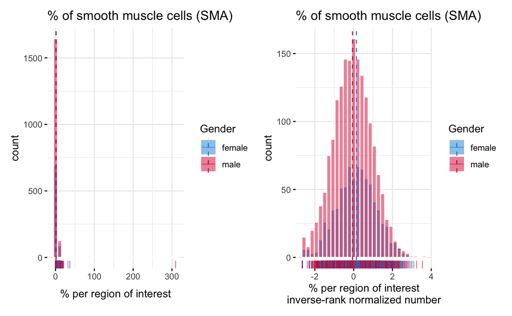

```r
p1 | p2
```

```r
p1 <- ggpubr::gghistogram(AEDB, "neutrophils",
                    # y = "..count..",
                    color = "white",
                    fill = "Gender",
                    palette = c("#1290D9", "#DB003F"),
                    add = "median",
                    #add_density = TRUE,
                    rug = TRUE,
                    #add.params =  list(color = "black", linetype = 2),
                    title = "number of neutrophils (CD66b)",
                    xlab = "counts per plaque",
                    ggtheme = theme_minimal())
```

```
Using `bins = 30` by default. Pick better value with the argument `bins`.
```

```r
p2 <- ggpubr::gghistogram(AEDB, "Neutrophils_rankNorm",
                    # y = "..count..",
                    color = "white",
                    fill = "Gender",
                    palette = c("#1290D9", "#DB003F"),
                    add = "median",
                    #add_density = TRUE,
                    rug = TRUE,
                    #add.params =  list(color = "black", linetype = 2),
                    title = "number of neutrophils (CD66b)",
                   xlab = "counts per plaque\ninverse-rank normalized number",
                    ggtheme = theme_minimal())
```

```
Using `bins = 30` by default. Pick better value with the argument `bins`.
```

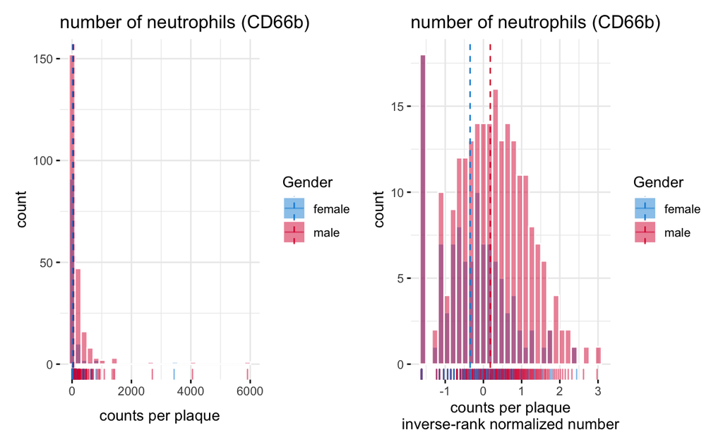

```r
p1 | p2
```

```r
p1 <- ggpubr::gghistogram(AEDB, "Mast_cells_plaque",
                    # y = "..count..",
                    color = "white",
                    fill = "Gender",
                    palette = c("#1290D9", "#DB003F"),
                    add = "median",
                    #add_density = TRUE,
                    rug = TRUE,
                    #add.params =  list(color = "black", linetype = 2),
                    title = "number of mast cells",
                    xlab = "counts per plaque",
                    ggtheme = theme_minimal())
```

```
Using `bins = 30` by default. Pick better value with the argument `bins`.
```

```r
p2 <- ggpubr::gghistogram(AEDB, "MastCells_rankNorm",
                    # y = "..count..",
                    color = "white",
                    fill = "Gender",
                    palette = c("#1290D9", "#DB003F"),
                    add = "median",
                    #add_density = TRUE,
                    rug = TRUE,
                    #add.params =  list(color = "black", linetype = 2),
                    title = "number of mast cells",
                   xlab = "counts per plaque\ninverse-rank normalized number",
                    ggtheme = theme_minimal())
```

```
Using `bins = 30` by default. Pick better value with the argument `bins`.
```

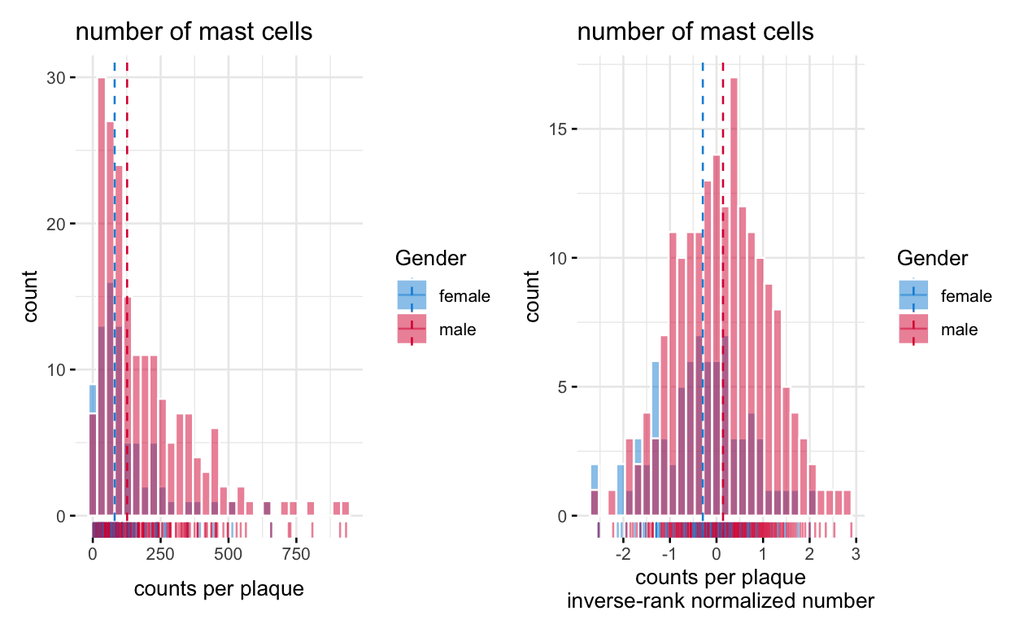

```r
p1 | p2
```

```r
p1 <- ggpubr::gghistogram(AEDB, "vessel_density_averaged",
                    # y = "..count..",
                    color = "white",
                    fill = "Gender",
                    palette = c("#1290D9", "#DB003F"),
                    add = "median",
                    #add_density = TRUE,
                    rug = TRUE,
                    #add.params =  list(color = "black", linetype = 2),
                    title = "number of intraplaque neovessels",
                    xlab = "counts per 3-4 hotspots",
                    ggtheme = theme_minimal())
```

```
Using `bins = 30` by default. Pick better value with the argument `bins`.
```

```r
p2 <- ggpubr::gghistogram(AEDB, "VesselDensity_rankNorm",
                    # y = "..count..",
                    color = "white",
                    fill = "Gender",
                    palette = c("#1290D9", "#DB003F"),
                    add = "median",
                    #add_density = TRUE,
                    rug = TRUE,
                    #add.params =  list(color = "black", linetype = 2),
                    title = "number of intraplaque neovessels",
                   xlab = "counts per 3-4 hotspots\ninverse-rank normalized number",
                    ggtheme = theme_minimal())
```

```
Using `bins = 30` by default. Pick better value with the argument `bins`.
```

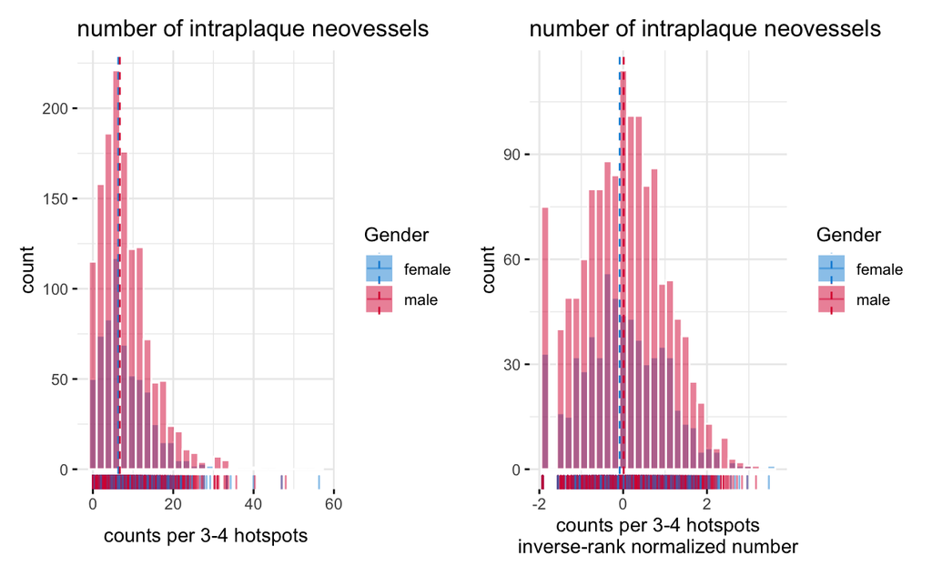

```r
p1 | p2
```

```r
rm(p1, p2)
```

Here we calculate the *plaque instability/vulnerability* index

```r
# Plaque vulnerability
```

```
There were 15 warnings (use warnings() to see them)
```

```r
require(labelled)
AEDB$Macrophages.bin <- to_factor(AEDB$Macrophages.bin)
AEDB$SMC.bin <- to_factor(AEDB$SMC.bin)
AEDB$IPH.bin <- to_factor(AEDB$IPH.bin)
AEDB$Calc.bin <- to_factor(AEDB$Calc.bin)
AEDB$Collagen.bin <- to_factor(AEDB$Collagen.bin)
AEDB$Fat.bin_10 <- to_factor(AEDB$Fat.bin_10)
AEDB$Fat.bin_40 <- to_factor(AEDB$Fat.bin_40)

table(AEDB$Macrophages.bin)
```

```
      no/minor moderate/heavy
          1602           1215
```

```r
table(AEDB$Fat.bin_10)
```

```
 <10%  >10%
 1226  1628
```

```r
table(AEDB$Collagen.bin)
```

```
      no/minor moderate/heavy
           540           2297
```

```r
table(AEDB$SMC.bin)
```

```
      no/minor moderate/heavy
           870           1962
```

```r
table(AEDB$IPH.bin)
```

```
  no  yes
1223 1628
```

```r
# SPSS code

#
# *** syntax- Plaque vulnerability**.
# COMPUTE Macro_instab = -999.
# IF macrophages.bin=2 Macro_instab=1.
# IF macrophages.bin=1 Macro_instab=0.
# EXECUTE.
#
# COMPUTE Fat10_instab = -999.
# IF Fat.bin_10=2 Fat10_instab=1.
# IF Fat.bin_10=1 Fat10_instab=0.
# EXECUTE.
#
# COMPUTE coll_instab=-999.
# IF Collagen.bin=2 coll_instab=0.
# IF Collagen.bin=1 coll_instab=1.
# EXECUTE.
#
#
# COMPUTE SMC_instab=-999.
# IF SMC.bin=2 SMC_instab=0.
# IF SMC.bin=1 SMC_instab=1.
# EXECUTE.
#
# COMPUTE IPH_instab=-999.
# IF IPH.bin=0 IPH_instab=0.
# IF IPH.bin=1 IPH_instab=1.
# EXECUTE.
#
# COMPUTE Instability=Macro_instab + Fat10_instab +  coll_instab + SMC_instab + IPH_instab.
# EXECUTE.

# Fix plaquephenotypes
attach(AEDB)
# mac instability
AEDB[,"MAC_Instability"] <- NA
AEDB$MAC_Instability[Macrophages.bin == -999] <- NA
AEDB$MAC_Instability[Macrophages.bin == "no/minor"] <- 0
AEDB$MAC_Instability[Macrophages.bin == "moderate/heavy"] <- 1

# fat instability
AEDB[,"FAT10_Instability"] <- NA
AEDB$FAT10_Instability[Fat.bin_10 == -999] <- NA
AEDB$FAT10_Instability[Fat.bin_10 == " <10%"] <- 0
AEDB$FAT10_Instability[Fat.bin_10 == " >10%"] <- 1

# col instability
AEDB[,"COL_Instability"] <- NA
AEDB$COL_Instability[Collagen.bin == -999] <- NA
AEDB$COL_Instability[Collagen.bin == "no/minor"] <- 1
AEDB$COL_Instability[Collagen.bin == "moderate/heavy"] <- 0

# smc instability
AEDB[,"SMC_Instability"] <- NA
AEDB$SMC_Instability[SMC.bin == -999] <- NA
AEDB$SMC_Instability[SMC.bin == "no/minor"] <- 1
AEDB$SMC_Instability[SMC.bin == "moderate/heavy"] <- 0

# iph instability
AEDB[,"IPH_Instability"] <- NA
AEDB$IPH_Instability[IPH.bin == -999] <- NA
AEDB$IPH_Instability[IPH.bin == "no"] <- 0
AEDB$IPH_Instability[IPH.bin == "yes"] <- 1

detach(AEDB)

table(AEDB$MAC_Instability, useNA = "ifany")
```

```
   0    1 <NA>
1602 1215  974
```

```r
table(AEDB$FAT10_Instability, useNA = "ifany")
```

```
   0    1 <NA>
1226 1628  937
```

```r
table(AEDB$COL_Instability, useNA = "ifany")
```

```
   0    1 <NA>
2297  540  954
```

```r
table(AEDB$SMC_Instability, useNA = "ifany")
```

```
   0    1 <NA>
1962  870  959
```

```r
table(AEDB$IPH_Instability, useNA = "ifany")
```

```
   0    1 <NA>
1223 1628  940
```

```r
# creating vulnerability index
AEDB <- AEDB %>% mutate(Plaque_Vulnerability_Index = factor(rowSums(.[grep("_Instability", names(.))], na.rm = TRUE)),
                                )
```

```
mutate: new variable 'Plaque_Vulnerability_Index' (factor) with 6 unique values and 0% NA
```

```r
table(AEDB$Plaque_Vulnerability_Index, useNA = "ifany")
```

```
   0    1    2    3    4    5
1324  655  728  676  298  110
```

```r
# str(AEDB$Plaque_Vulnerability_Index)
```

### 4.1.3 Prepare baseline characteristics

We are interested in the following variables at baseline.

- Age (years)
- Female sex (N, %)
- Hypertension (N, %)
- SBP (mmHg)
- DBP (mmHg)
- Diabetes mellitus (N, %)
- Total cholesterol levels (mg/dL)
- LDL cholesterol levels (mg/dL)
- HDL cholesterol levels (mg/dL)
- Triglyceride levels (mg/dL)
- Use of statins (N, %)
- Use of antiplatelet drugs (N, %)
- BMI (kg/m²)
- Smoking status (N, %)
  - Never smokers
  - Ex-smokers
  - Current smokers
- History of CAD (N, %)
- History of PAD (N, %)
- Clinical manifestations
  - Asymptomatic
  - Amaurosis fugax
  - TIA
  - Stroke
- eGFR (mL/min/1.73 m²)
- stenosis
- year of surgery
- plaque characteristics

```r
cat("====================================================================================================\n")
cat("SELECTION THE SHIZZLE\n")
```

```
SELECTION THE SHIZZLE
```

```r
### Artery levels
# AEdata$Artery_summary:
#           value                                                                                   label
# NOT USE - 0 No artery known (yet), no surgery (patient ill, died, exited study), re-numbered to AAA
# USE - 1                                                                  carotid (left & right)
# USE - 2                                               femoral/iliac (left, right or both sides)
# NOT USE - 3                                               other carotid arteries (common, external)
# NOT USE - 4                                   carotid bypass and injury (left, right or both sides)
# NOT USE - 5                                                         aneurysmata (carotid & femoral)
# NOT USE - 6                                                                                   aorta
# NOT USE - 7                                            other arteries (renal, popliteal, vertebral)
# NOT USE - 8                        femoral bypass, angioseal and injury (left, right or both sides)

### AEdata$informedconsent
#           value                                                                                           label
# NOT USE - -999                                                                                         missing
# NOT USE - 0                                                                                        no, died
# USE - 1                                                                                             yes
# USE - 2                                                             yes, health treatment when possible
# USE - 3                                                                        yes, no health treatment
# USE - 4                                                yes, no health treatment, no commercial business
# NOT USE - 5                                                          yes, no tissue, no commerical business
# NOT USE - 6                      yes, no tissue, no questionnaires, no medical info, no commercial business
# USE - 7                             yes, no questionnaires, no health treatment, no commercial business
# USE - 8                                          yes, no questionnaires, health treatment when possible
# NOT USE - 9                  yes, no tissue, no questionnaires, no health treatment, no commerical business
# USE - 10                               yes, no health treatment, no medical info, no commercial business
# NOT USE - 11 yes, no tissue, no questionnaires, no health treatment, no medical info, no commercial business
# USE - 12                                                     yes, no questionnaires, no health treatment
# NOT USE - 13                                                             yes, no tissue, no health treatment
# NOT USE - 14                                                               yes, no tissue, no questionnaires
# NOT USE - 15                                                  yes, no tissue, health treatment when possible
# NOT USE - 16                                                                                  yes, no tissue
# USE - 17                                                                     yes, no commerical business
# USE - 18                                     yes, health treatment when possible, no commercial business
# USE - 19                                                    yes, no medical info, no commercial business
# USE - 20                                                                          yes, no questionnaires
# NOT USE - 21                         yes, no tissue, no questionnaires, no health treatment, no medical info
# NOT USE - 22                  yes, no tissue, no questionnaires, no health treatment, no commercial business
# USE - 23                                                                            yes, no medical info
# USE - 24                                                  yes, no questionnaires, no commercial business
# USE - 25                                    yes, no questionnaires, no health treatment, no medical info
# USE - 26                  yes, no questionnaires, health treatment when possible, no commercial business
# USE - 27                                                      yes,  no health treatment, no medical info
# NOT USE - 28                                                                             no, doesn't want to
# NOT USE - 29                                                                              no, unable to sign
# NOT USE - 30                                                                                 no, no reaction
# NOT USE - 31                                                                                        no, lost
# NOT USE - 32                                                                                     no, too old
# NOT USE - 34                                            yes, no medical info, health treatment when possible
# NOT USE - 35                                             no (never asked for IC because there was no tissue)
# USE - 36                    yes, no medical info, no commercial business, health treatment when possible
# NOT USE - 37                                                                                    no, endpoint
# USE - 38                                                         wil niets invullen, wel alles gebruiken
# USE - 39                                           second informed concents: yes, no commercial business
# NOT USE - 40                                                                              nooit geincludeerd

cat("- sanity checking PRIOR to selection")
```

```
- sanity checking PRIOR to selection
```

```r
library(data.table)
require(labelled)
ae.gender <- to_factor(AEDB$Gender)
ae.hospital <- to_factor(AEDB$Hospital)
table(ae.gender, ae.hospital, dnn = c("Sex", "Hospital"))
```

```
        Hospital
Sex      St. Antonius, Nieuwegein UMC Utrecht
  female                      524         636
  male                       1211        1420
```

```r
ae.artery <- to_factor(AEDB$Artery_summary)
table(ae.artery, ae.gender, dnn = c("Sex", "Artery"))
```

```
                                                                                         Artery
Sex                                                                                       female male
  No artery known (yet), no surgery (patient ill, died, exited study), re-numbered to AAA      0    0
  carotid (left & right)                                                                     805 1781
  femoral/iliac (left, right or both sides)                                                  320  796
  other carotid arteries (common, external)                                                   17   35
  carotid bypass and injury (left, right or both sides)                                        6    3
  aneurysmata (carotid & femoral)                                                              1    0
  aorta                                                                                        3    5
  other arteries (renal, popliteal, vertebral)                                                 4    9
  femoral bypass, angioseal and injury (left, right or both sides)                             4    2
```

```r
rm(ae.gender, ae.hospital, ae.artery)

# I change numeric and factors manually because, well, I wouldn't know how to fix it otherwise
# to have this 'tibble' work with 'tableone'... :-)

AEDB$Age <- as.numeric(AEDB$Age)
AEDB$diastoli <- as.numeric(AEDB$diastoli)
AEDB$systolic <- as.numeric(AEDB$systolic)

AEDB$TC_finalCU <- as.numeric(AEDB$TC_finalCU)
AEDB$LDL_finalCU <- as.numeric(AEDB$LDL_finalCU)
AEDB$HDL_finalCU <- as.numeric(AEDB$HDL_finalCU)
AEDB$TG_finalCU <- as.numeric(AEDB$TG_finalCU)

AEDB$TC_final <- as.numeric(AEDB$TC_final)
AEDB$LDL_final <- as.numeric(AEDB$LDL_final)
AEDB$HDL_final <- as.numeric(AEDB$HDL_final)
AEDB$TG_final <- as.numeric(AEDB$TG_final)

AEDB$Age <- as.numeric(AEDB$Age)
AEDB$GFR_MDRD <- as.numeric(AEDB$GFR_MDRD)
AEDB$BMI <- as.numeric(AEDB$BMI)
AEDB$eCigarettes <- as.numeric(AEDB$eCigarettes)
AEDB$ePackYearsSmoking <- as.numeric(AEDB$ePackYearsSmoking)
AEDB$EP_composite_time <- as.numeric(AEDB$EP_composite_time)
AEDB$EP_major_time <- as.numeric(AEDB$EP_major_time)

require(labelled)
AEDB$ORyear <- to_factor(AEDB$ORyear)
AEDB$Gender <- to_factor(AEDB$Gender)
AEDB$Hospital <- to_factor(AEDB$Hospital)
AEDB$KDOQI <- to_factor(AEDB$KDOQI)
AEDB$BMI_WHO <- to_factor(AEDB$BMI_WHO)
AEDB$DiabetesStatus <- to_factor(AEDB$DiabetesStatus)
AEDB$SmokerStatus <- to_factor(AEDB$SmokerStatus)
AEDB$AlcoholUse <- to_factor(AEDB$AlcoholUse)

AEDB$Hypertension.selfreport <- to_factor(AEDB$Hypertension1)
AEDB$Hypertension.selfreportdrug <- to_factor(AEDB$Hypertension2)
AEDB$Hypertension.composite <- to_factor(AEDB$Hypertension.composite)
AEDB$Hypertension.drugs <- to_factor(AEDB$Hypertension.drugs)

AEDB$Med.anticoagulants <- to_factor(AEDB$Med.anticoagulants)
AEDB$Med.all.antiplatelet <- to_factor(AEDB$Med.all.antiplatelet)
AEDB$Med.Statin.LLD <- to_factor(AEDB$Med.Statin.LLD)

AEDB$Stroke_Dx <- to_factor(AEDB$Stroke_Dx)
AEDB$CAD_history <- to_factor(AEDB$CAD_history)
AEDB$PAOD <- to_factor(AEDB$PAOD)
AEDB$Peripheral.interv <- to_factor(AEDB$Peripheral.interv)

AEDB$sympt <- to_factor(AEDB$sympt)
AEDB$Symptoms.3g <- to_factor(AEDB$Symptoms.3g)
AEDB$Symptoms.4g <- to_factor(AEDB$Symptoms.4g)
AEDB$Symptoms.5G <- to_factor(AEDB$Symptoms.5G)
AEDB$AsymptSympt <- to_factor(AEDB$AsymptSympt)
AEDB$AsymptSympt2G <- to_factor(AEDB$AsymptSympt2G)

AEDB$restenos <- to_factor(AEDB$restenos)
AEDB$stenose <- to_factor(AEDB$stenose)
AEDB$EP_composite <- to_factor(AEDB$EP_composite)
AEDB$EP_major <- to_factor(AEDB$EP_major)
AEDB$Macrophages.bin <- to_factor(AEDB$Macrophages.bin)
AEDB$SMC.bin <- to_factor(AEDB$SMC.bin)
AEDB$IPH.bin <- to_factor(AEDB$IPH.bin)
AEDB$Calc.bin <- to_factor(AEDB$Calc.bin)
AEDB$Collagen.bin <- to_factor(AEDB$Collagen.bin)
AEDB$Fat.bin_10 <- to_factor(AEDB$Fat.bin_10)
AEDB$Fat.bin_40 <- to_factor(AEDB$Fat.bin_40)
AEDB$OverallPlaquePhenotype <- to_factor(AEDB$OverallPlaquePhenotype)
AEDB$Plaque_Vulnerability_Index <- to_factor(AEDB$Plaque_Vulnerability_Index)

AEDB$Artery_summary <- to_factor(AEDB$Artery_summary)

AEDB$informedconsent <- to_factor(AEDB$informedconsent)

AEDB.CEA <- subset(AEDB,
                    (Artery_summary == "carotid (left & right)" | Artery_summary == "other carotid arteries (common, external)") & # we only want carotids
                       informedconsent != "missing" & # we are really strict in selecting based on 'informed consent'!
                       informedconsent != "no, died" &
                       informedconsent != "yes, no tissue, no commerical business" &
                       informedconsent != "yes, no tissue, no questionnaires, no medical info, no commercial business" &
                       informedconsent != "yes, no tissue, no questionnaires, no health treatment, no commerical business" &
                       informedconsent != "yes, no tissue, no questionnaires, no health treatment, no medical info, no commercial business" &
                       informedconsent != "yes, no tissue, no health treatment" &
                       informedconsent != "yes, no tissue, no questionnaires" &
                       informedconsent != "yes, no tissue, health treatment when possible" &
                       informedconsent != "yes, no tissue" &
                       informedconsent != "yes, no tissue, no questionnaires, no health treatment, no medical info" &
                       informedconsent != "yes, no tissue, no questionnaires, no health treatment, no commercial business" &
                       informedconsent != "no, doesn't want to" &
                       informedconsent != "no, unable to sign" &
                       informedconsent != "no, no reaction" &
                       informedconsent != "no, lost" &
                       informedconsent != "no, too old" &
                       informedconsent != "yes, no medical info, health treatment when possible" &
                       informedconsent != "no (never asked for IC because there was no tissue)" &
                       informedconsent != "no, endpoint" &
                       informedconsent != "nooit geincludeerd")
# AEDB.CEA[1:10, 1:10]
dim(AEDB.CEA)
```

```
[1] 2432 1111
```

```r
AEDB.full <- subset(AEDB,
                    informedconsent != "missing" & # we are really strict in selecting based on 'informed consent'!
                       informedconsent != "no, died" &
                       informedconsent != "yes, no tissue, no commerical business" &
                       informedconsent != "yes, no tissue, no questionnaires, no medical info, no commercial business" &
                       informedconsent != "yes, no tissue, no questionnaires, no health treatment, no commerical business" &
                       informedconsent != "yes, no tissue, no questionnaires, no health treatment, no medical info, no commercial business" &
                       informedconsent != "yes, no tissue, no health treatment" &
                       informedconsent != "yes, no tissue, no questionnaires" &
                       informedconsent != "yes, no tissue, health treatment when possible" &
                       informedconsent != "yes, no tissue" &
                       informedconsent != "yes, no tissue, no questionnaires, no health treatment, no medical info" &
                       informedconsent != "yes, no tissue, no questionnaires, no health treatment, no commercial business" &
                       informedconsent != "no, doesn't want to" &
                       informedconsent != "no, unable to sign" &
                       informedconsent != "no, no reaction" &
                       informedconsent != "no, lost" &
                       informedconsent != "no, too old" &
                       informedconsent != "yes, no medical info, health treatment when possible" &
                       informedconsent != "no (never asked for IC because there was no tissue)" &
                       informedconsent != "no, endpoint" &
                       informedconsent != "nooit geincludeerd")
# AEDB.CEA[1:10, 1:10]
dim(AEDB.full)
```

```
[1] 3458 1111
```

```r
cat("===========================================================================================\n")
cat("CREATE BASELINE TABLE\n")
```

```
CREATE BASELINE TABLE
```

```r
# Baseline table variables
basetable_vars = c("Hospital", "ORyear",
                   "Age", "Gender",
                   # "TC_finalCU", "LDL_finalCU", "HDL_finalCU", "TG_finalCU",
                   "TC_final", "LDL_final", "HDL_final", "TG_final",
                   # "hsCRP_plasma",
                   "systolic", "diastoli", "GFR_MDRD", "BMI",
                   "KDOQI", "BMI_WHO",
                   "SmokerStatus", "AlcoholUse",
                   "DiabetesStatus",
                   "Hypertension.selfreport", "Hypertension.selfreportdrug", "Hypertension.composite", "Hypertension.drugs",
                   "Med.anticoagulants", "Med.all.antiplatelet", "Med.Statin.LLD",
                   "Stroke_Dx", "sympt", "Symptoms.5G", "AsymptSympt", "AsymptSympt2G",
                   "restenos", "stenose",
                   "CAD_history", "PAOD", "Peripheral.interv",
                   "EP_composite", "EP_composite_time", "EP_major", "EP_major_time",
                   "MAC_rankNorm", "SMC_rankNorm", "Macrophages.bin", "SMC.bin",
                   "Neutrophils_rankNorm", "MastCells_rankNorm",
                   "IPH.bin", "VesselDensity_rankNorm",
                   "Calc.bin", "Collagen.bin",
                   "Fat.bin_10", "Fat.bin_40", "OverallPlaquePhenotype", "Plaque_Vulnerability_Index")

basetable_bin = c("Gender",
                  "KDOQI", "BMI_WHO",
                  "SmokerStatus", "AlcoholUse",
                  "DiabetesStatus",
                  "Hypertension.selfreport", "Hypertension.selfreportdrug", "Hypertension.composite", "Hypertension.drugs",
                  "Med.anticoagulants", "Med.all.antiplatelet", "Med.Statin.LLD",
                  "Stroke_Dx", "sympt", "Symptoms.5G", "AsymptSympt", "AsymptSympt2G",
                  "restenos", "stenose",
                  "CAD_history", "PAOD", "Peripheral.interv",
                  "EP_composite", "Macrophages.bin", "SMC.bin",
                  "IPH.bin",
                  "Calc.bin", "Collagen.bin",
                  "Fat.bin_10", "Fat.bin_40", "OverallPlaquePhenotype", "Plaque_Vulnerability_Index")
# basetable_bin

basetable_con = basetable_vars[!basetable_vars %in% basetable_bin]
# basetable_con
```

### 4.1.4 Baseline characteristics

Showing the baseline table of the whole Athero-Express Biobank.

```r
# Create baseline tables
# http://rstudio-pubs-static.s3.amazonaws.com/13321_da314633db924dc78986a850813a50d5.html
AEDB.tableOne = print(CreateTableOne(vars = basetable_vars,
                                         # factorVars = basetable_bin,
                                         # strata = "Symptoms.4g",
                                         data = AEDB.full, includeNA = TRUE),
                          nonnormal = c(), missing = TRUE,
                          quote = FALSE, noSpaces = FALSE, showAllLevels = TRUE, explain = TRUE,
                          format = "pf",
                          contDigits = 3)[,1:3]
```

```
                                       level
  n
  Hospital % (freq)                    St. Antonius, Nieuwegein
                                       UMC Utrecht
  ORyear % (freq)                      No data available/missing
                                       2002
                                       2003
                                       2004
                                       2005
                                       2006
                                       2007
                                       2008
                                       2009
                                       2010
                                       2011
                                       2012
                                       2013
                                       2014
                                       2015
                                       2016
                                       2017
                                       2018
                                       2019
  Age (mean (SD))
  Gender % (freq)                      female
                                       male
  TC_final (mean (SD))
  LDL_final (mean (SD))
  HDL_final (mean (SD))
  TG_final (mean (SD))
  systolic (mean (SD))
  diastoli (mean (SD))
  GFR_MDRD (mean (SD))
  BMI (mean (SD))
  KDOQI % (freq)                       No data available/missing
                                       Normal kidney function
                                       CKD 2 (Mild)
                                       CKD 3 (Moderate)
                                       CKD 4 (Severe)
                                       CKD 5 (Failure)
```

[output cut: 336 more lines]

```
                                          43.0 (1488)
                                          25.3 ( 874)
  Fat.bin_40 % (freq)                     59.5 (2056)   25.3
                                          15.3 ( 528)
                                          25.3 ( 874)
  OverallPlaquePhenotype % (freq)         14.7 ( 507)   25.9
                                          22.2 ( 769)
                                          37.2 (1285)
                                          25.9 ( 897)
  Plaque_Vulnerability_Index % (freq)     35.0 (1212)    0.0
                                          17.1 ( 590)
                                          19.0 ( 657)
                                          18.0 ( 622)
                                           8.0 ( 277)
                                           2.9 ( 100)
```

```r
# Create baseline tables
# http://rstudio-pubs-static.s3.amazonaws.com/13321_da314633db924dc78986a850813a50d5.html
AEDB.CEA.tableOne = print(CreateTableOne(vars = basetable_vars,
                                         # factorVars = basetable_bin,
                                         # strata = "Symptoms.4g",
                                         data = AEDB.CEA, includeNA = TRUE),
                          nonnormal = c(), missing = TRUE,
                          quote = FALSE, noSpaces = FALSE, showAllLevels = TRUE, explain = TRUE,
                          format = "pf",
                          contDigits = 3)[,1:3]
```

```
                                       level
  n
  Hospital % (freq)                    St. Antonius, Nieuwegein
                                       UMC Utrecht
  ORyear % (freq)                      No data available/missing
                                       2002
                                       2003
                                       2004
                                       2005
                                       2006
                                       2007
                                       2008
                                       2009
                                       2010
                                       2011
                                       2012
                                       2013
                                       2014
                                       2015
                                       2016
                                       2017
                                       2018
                                       2019
  Age (mean (SD))
  Gender % (freq)                      female
                                       male
  TC_final (mean (SD))
  LDL_final (mean (SD))
  HDL_final (mean (SD))
  TG_final (mean (SD))
  systolic (mean (SD))
  diastoli (mean (SD))
  GFR_MDRD (mean (SD))
  BMI (mean (SD))
  KDOQI % (freq)                       No data available/missing
                                       Normal kidney function
                                       CKD 2 (Mild)
                                       CKD 3 (Moderate)
                                       CKD 4 (Severe)
                                       CKD 5 (Failure)
```

[output cut: 336 more lines]

```
                                          54.3 (1321)
                                          23.4 ( 568)
  Fat.bin_40 % (freq)                     56.2 (1367)   23.4
                                          20.4 ( 497)
                                          23.4 ( 568)
  OverallPlaquePhenotype % (freq)         19.8 ( 481)   23.7
                                          27.8 ( 677)
                                          28.7 ( 697)
                                          23.7 ( 577)
  Plaque_Vulnerability_Index % (freq)     29.4 ( 716)    0.0
                                          14.4 ( 349)
                                          19.8 ( 481)
                                          22.0 ( 536)
                                          10.4 ( 252)
                                           4.0 (  98)
```

## 4.2 Athero-Express RNAseq Study

Loading RNAseq data.

```r
# bulk RNAseq data

# used the first time
# bulkRNA_counts <- fread(paste0(AERNA_loc, "/2019-12-11_bulk_RNAseq_data_to_share/bulk_RNAseq_raw_counts_corrected_for_UMI.txt"))
bulkRNA_counts <- fread(paste0(AERNA_loc,"/2019-12-11_bulk_RNAseq_data_to_share/bulk_RNAseq_raw_counts_UMIcorr_weird_genes_filtered.txt"))

# batch information
bulkRNA_meta <- fread(paste0(AERNA_loc,"/2019-12-11_bulk_RNAseq_data_to_share/bulk_RNAseq_metadata.txt"))

# fix study numbers
bulkRNA_meta$study_number <- as.numeric(stringi::stri_replace_last_regex(bulkRNA_meta$study_number, "^ae*", ""))

names(bulkRNA_counts) <- stringi::stri_replace_last_regex(names(bulkRNA_counts), "^ae*", "")
```

Quick peek at the counts and meta-data of the RNAseq experiment.

```r
head(bulkRNA_counts)
```

```
'head' showing 6 out of 660 columns!
```

|  | ensembl_gene_id | symbol | chr | start | end | strand |
| --- | --- | --- | --- | --- | --- | --- |
| 1 | ENSG00000184389 | A3GALT2 | 01 | 33772367 | 33786699 | - |
| 2 | ENSG00000188984 | AADACL3 | 01 | 12776118 | 12788726 | + |
| 3 | ENSG00000204518 | AADACL4 | 01 | 12704566 | 12727097 | + |
| 4 | ENSG00000198691 | ABCA4 | 01 | 94458393 | 94586688 | - |
| 5 | ENSG00000135776 | ABCB10 | 01 | 229652329 | 229694442 | - |
| 6 | ENSG00000117528 | ABCD3 | 01 | 94883933 | 94984222 | + |

```r
head(bulkRNA_meta)
```

|  | study_number | batch | batchnr | pool |
| --- | --- | --- | --- | --- |
| 1 | 1 | 10 | 3219 | 9 |
| 2 | 1026 | 3 | 3212 | 8 |
| 3 | 1029 | 4 | 3213 | 3 |
| 4 | 1032 | 6 | 3215 | 3 |
| 5 | 1035 | 1 | 3210 | 5 |
| 6 | 1054 | 6 | 3215 | 9 |

We will parse the RNAseq data for downstream use.

```r
AEDB.CEA.sampleList <- AEDB.CEA$STUDY_NUMBER
# match up with meta data of RNAseq experiment
bulkRNA_counts %<>%
     drop_na(chr) %>%   # remove rows that have no information of start, end, chromosome and/or strand
     dplyr::select(1:6, one_of(sort(as.character(AEDB.CEA.sampleList)))) # select gene expression of only patients in RNA-seq AE df, sort in same order as metadata study_number
```

[output not shown]

```r
# Cut up bulkRNA_counts into 'assay' and 'ranges' part
counts <- as.data.frame(bulkRNA_counts[,-(1:6)])              ## assay part
rownames(counts) <- bulkRNA_counts$ensembl_gene_id               ## assign rownames
bulkRNA_rowRanges <- GRanges(bulkRNA_counts$chr,                    ## construct a GRanges object containing 4 columns (seqnames, ranges, strand, seqinfo) plus a metadata colum (feature_id): this will be the 'rowRanges' bit
                     IRanges(bulkRNA_counts$start, bulkRNA_counts$end),
                     strand = bulkRNA_counts$strand,
                     feature_id = bulkRNA_counts$ensembl_gene_id) #, df$pid)
names(bulkRNA_rowRanges) <- bulkRNA_rowRanges$feature_id

# ?org.Hs.eg.db
# ?AnnotationDb

bulkRNA_rowRanges$symbol <- mapIds(org.Hs.eg.db,
                     keys = bulkRNA_rowRanges$feature_id,
                     column = "SYMBOL",
                     keytype = "ENSEMBL",
                     multiVals = "first")
# Reference: https://shiring.github.io/genome/2016/10/23/AnnotationDbi

# gene dataframe for EnsDb.Hsapiens.v86
gene_dataframe_EnsDb <- ensembldb::select(EnsDb.Hsapiens.v86, keys = bulkRNA_rowRanges$feature_id,
                                          columns = c("ENTREZID", "SYMBOL", "GENEBIOTYPE"), keytype = "GENEID")
colnames(gene_dataframe_EnsDb) <- c("Ensembl", "Entrez", "HGNC", "GENEBIOTYPE")
colnames(gene_dataframe_EnsDb) <- paste(colnames(gene_dataframe_EnsDb), "EnsDb86", sep = "_")
head(gene_dataframe_EnsDb)
```

|  | Ensembl_EnsDb86 | Entrez_EnsDb86 | HGNC_EnsDb86 | GENEBIOTYPE_EnsDb86 |
| --- | --- | --- | --- | --- |
| 1 | ENSG00000184389 | 127550 | A3GALT2 | protein_coding |
| 2 | ENSG00000188984 | 126767 | AADACL3 | protein_coding |
| 3 | ENSG00000204518 | 343066 | AADACL4 | protein_coding |
| 4 | ENSG00000198691 | 24 | ABCA4 | protein_coding |
| 5 | ENSG00000135776 | 23456 | ABCB10 | protein_coding |
| 6 | ENSG00000117528 | 5825 | ABCD3 | protein_coding |

```r
bulkRNA_rowRanges$GENEBIOTYPE_EnsDb86 <- gene_dataframe_EnsDb$GENEBIOTYPE_EnsDb86[match(bulkRNA_rowRanges$feature_id, gene_dataframe_EnsDb$Ensembl_EnsDb86)]
bulkRNA_rowRanges
```

```
GRanges object with 53197 ranges and 3 metadata columns:
                  seqnames              ranges strand |      feature_id      symbol  GENEBIOTYPE_EnsDb86
                     <Rle>           <IRanges>  <Rle> |     <character> <character>          <character>
  ENSG00000184389       01   33772367-33786699      - | ENSG00000184389     A3GALT2       protein_coding
  ENSG00000188984       01   12776118-12788726      + | ENSG00000188984     AADACL3       protein_coding
  ENSG00000204518       01   12704566-12727097      + | ENSG00000204518     AADACL4       protein_coding
  ENSG00000198691       01   94458393-94586688      - | ENSG00000198691       ABCA4       protein_coding
  ENSG00000135776       01 229652329-229694442      - | ENSG00000135776      ABCB10       protein_coding
              ...      ...                 ...    ... .             ...         ...                  ...
  ENSG00000270242       0Y   13551375-13552752      + | ENSG00000270242        <NA> processed_pseudogene
  ENSG00000270455       0Y   13491303-13493369      + | ENSG00000270455        <NA> processed_pseudogene
  ENSG00000271123       0Y   23793569-23793901      - | ENSG00000271123        <NA> processed_pseudogene
  ENSG00000271375       0Y   13629403-13629913      - | ENSG00000271375        <NA> processed_pseudogene
  ENSG00000271595       0Y   19576759-19577094      - | ENSG00000271595        <NA> processed_pseudogene
  -------
  seqinfo: 124 sequences from an unspecified genome; no seqlengths
```

```r
# merging the two dataframes by HGNC
# bulkRNA_rowRangesHg19Ensemblb86 <- GRanges(merge(bulkRNA_rowRanges, gene_dataframe_EnsDb, by.x = "feature_id", by.y = "Ensembl_EnsDb86", sort = FALSE, all.x = TRUE))
# names(bulkRNA_rowRangesHg19Ensemblb86) <- bulkRNA_rowRangesHg19Ensemblb86$feature_id
# bulkRNA_rowRangesHg19Ensemblb86

# temp <- as.data.frame(table(bulkRNA_rowRanges$GENEBIOTYPE_EnsDb86))
# colnames(temp) <- c("GeneBiotype", "Count")
#
# ggpubr::ggbarplot(temp, x = "GeneBiotype", y = "Count",
#                   color = "GeneBiotype", fill = "GeneBiotype",
#                   xlab = "gene type") +
#   theme(axis.text.x = element_text(angle = 45))
# rm(temp)
```

```r
# match up with meta data of RNAseq experiment
bulkRNA_meta %<>%
     dplyr::filter(study_number %in% AEDB.CEA.sampleList) # select gene expression of only patients in RNA-seq AE df, sort in same order as metadata study_number

# combine meta data from experiment with clinical data
bulkRNA_meta_clin <- merge(bulkRNA_meta, AEDB.CEA, by.x = "study_number", by.y = "STUDY_NUMBER",
                           sort = FALSE, all.x = TRUE)

bulkRNA_meta_clin %<>%
  # mutate(macrophages = factor(macrophages, levels = c("no staining", "minor staining", "moderate staining", "heavy staining"))) %>%
  # mutate(smc = factor(smc, levels = c("no staining", "minor staining", "moderate staining", "heavy staining"))) %>%
  # mutate(calcification = factor(calcification, levels = c("no staining", "minor staining", "moderate staining", "heavy staining"))) %>%
  # mutate(collagen = factor(collagen, levels = c("no staining", "minor staining", "moderate staining", "heavy staining"))) %>%
  # mutate(fat = factor(fat, levels = c("no fat", "< 40% fat", "> 40% fat"))) %>%
  mutate(study_number_row = study_number) %>%
  as.data.frame() %>%
  column_to_rownames("study_number_row")
```

```
mutate: new variable 'study_number_row' (double) with 622 unique values and 0% NA
```

```r
head(bulkRNA_meta_clin)
```

```
'head' showing 6 out of 1114 columns!
```

|  | study_number | batch | batchnr | pool | UPID | AE_AAA_bijzonderheden |
| --- | --- | --- | --- | --- | --- | --- |
| 1 | 1 | 10 | 3219 | 9 | UPID04067 | NA |
| 1026 | 1026 | 3 | 3212 | 8 | UPID00984 | NA |
| 1029 | 1029 | 4 | 3213 | 3 | UPID00790 | NA |
| 1032 | 1032 | 6 | 3215 | 3 | UPID00117 | 3 |
| 1054 | 1054 | 6 | 3215 | 9 | UPID00777 | NA |
| 1055 | 1055 | 10 | 3219 | 7 | UPID00879 | NA |

```r
dim(bulkRNA_meta_clin)
```

```
[1]  622 1114
```

We make a `SummarizedExperiment` for the RNAseq data.

```r
cat("* loading data ...\n")
```

```
* loading data ...
```

```r
# this is all the data passing RNAseq quality control
# - includes 654 patients
# - after filtering on informed consent, the end sample size should be 632
AERNA_UMIcorr <- bulkRNA_counts

# cat("* head of the update data ...\n")
# DT::datatable(head(AERNA_UMIcorr))

cat("\n* making a SummarizedExperiment ...")
```

```
* making a SummarizedExperiment ...
```

```r
temp <- matrix(as.numeric(unlist(AERNA_UMIcorr[7:628])),
               nrow = nrow(AERNA_UMIcorr), # number of features in the assay, i.e. genes, probes, etc
               ncol = ncol(AERNA_UMIcorr[,7:628]), # number of samples
               byrow = TRUE,
               dimnames = list(c(AERNA_UMIcorr$ensembl_gene_id), c(names(AERNA_UMIcorr[,7:628]))) )
```

```
NAs introduced by coerciondata length [390616] is not a sub-multiple or multiple of the number of rows [53197]
```

```r
# str(temp)
temp_coldat <- data.frame(STUDY_NUMBER = names(AERNA_UMIcorr[,7:628]),
                          SampleType = "plaque", RNAseqType = "3' RNAseq",
                          row.names = names(AERNA_UMIcorr[,7:628]))


AERNA_UMIcorrSE <- SummarizedExperiment(assays = temp, colData = temp_coldat, rowRanges = bulkRNA_rowRanges)
AERNA_UMIcorrSE
```

```
class: RangedSummarizedExperiment
dim: 53197 622
metadata(0):
assays(1): ''
rownames(53197): ENSG00000184389 ENSG00000188984 ... ENSG00000271375 ENSG00000271595
rowData names(3): feature_id symbol GENEBIOTYPE_EnsDb86
colnames(622): 1 1026 ... 998 999
colData names(3): STUDY_NUMBER SampleType RNAseqType
```

```r
cat("\n* removing intermediate files ...\n")
```

```
* removing intermediate files ...
```

```r
rm(temp, temp_coldat)
```

## 4.3 Athero-Express Methylation Study

Loading the *Athero-Express Methylation Study* datasets (*AEMS450K1* and *AEMS450K2*).

```r
cat("\n  - loading B/Mvalues of plaque samples in AEMS450K1 ...")
```

```
  - loading B/Mvalues of plaque samples in AEMS450K1 ...
```

```r
#load(paste0(AEMS450K1_loc,"/20180625.aems450k1.BvaluesQCIMPSE.plaque.RData"))
load(paste0(AEMS450K1_loc,"/20180625.aems450k1.MvaluesQCIMPSE.plaque.RData"))

cat("\n  - loading B/Mvalues of plaque samples in AEMS450K2 ...")
```

```
  - loading B/Mvalues of plaque samples in AEMS450K2 ...
```

```r
#load(paste0(AEMS450K2_loc,"/20180625.aems450k2.BvaluesQCIMPSE.plaque.RData"))
load(paste0(AEMS450K2_loc,"/20180625.aems450k2.MvaluesQCIMPSE.plaque.RData"))
```

### 4.3.1 Update

We will use the [DNAmArray Workflow](https://molepi.github.io/DNAmArray_workflow)[^4] developed by the group of prof. dr. Bastiaan Heijmans to update our `SummarizedExperiment()`-objects. This will mask, *i.e.* remove, probes that are deemed problematic (see **Introduction**).

References:

- https://rpubs.com/zhouwanding/417953
- https://zwdzwd.github.io/InfiniumAnnotation

#### 4.3.1.1 Masking files

We load the various masking-files.

##### 4.3.1.1.1 Zhou et al.

```r
hm450.hg19.manifest.180909 <- readRDS(file = url("http://zwdzwd.io/InfiniumAnnotation/20180909/HM450/HM450.hg19.manifest.rds"),
        "rb")

head(hm450.hg19.manifest.180909)
```

```
GRanges object with 6 ranges and 52 metadata columns:
             seqnames      ranges strand | address_A address_B     channel  designType    nextBase nextBaseRef   probeType
                <Rle>   <IRanges>  <Rle> | <integer> <integer> <character> <character> <character> <character> <character>
  cg13869341     chr1 15865-15866      - |  62703328  16661461         Red           I           A           C          cg
  cg14008030     chr1 18827-18828      - |  27651330      <NA>        Both          II         G/A           C          cg
  cg12045430     chr1 29407-29408      - |  25703424  34666387         Red           I           A           C          cg
  cg20826792     chr1 29425-29426      - |  61731400  14693326         Red           I           T           A          cg
  cg00381604     chr1 29435-29436      - |  26752380  50693408         Red           I           A           T          cg
  cg20253340     chr1 68849-68850      - |  49752305      <NA>        Both          II         G/A           C          cg
             orientation probeCpGcnt context35  probeBeg  probeEnd                                         ProbeSeq_A
             <character>   <integer> <integer> <integer> <numeric>                                        <character>
  cg13869341        down           2         4     15865     15914 CCAATAACTAACCACTCTACTAAAATCCATCCACCAAACTAAAAACATCA
  cg14008030        down           2         3     18828     18877 ACTCRAAATTTACTCAATAAACCRTTCAATATATACAAAAACAATTCCCC
  cg12045430        down           8        11     29407     29456 AAAAAAAACACAATAAAAAACAAACAACAACATTAAAACCCAAAAACACA
  cg20826792        down           7        12     29425     29474 AATCCTAAAACCACACTCAAAAAAAACACAATAAAAAACAAACAACAACA
  cg00381604        down           7        12     29435     29484 AAATCAACAAAATCCTAAAACCACACTCAAAAAAAACACAATAAAAAACA
  cg20253340        down           1         1     68850     68899 ATTCTATCTCRCACTACTTCCCTAACTATACCTTATAATTCAATTATCTC
                                                     ProbeSeq_B                          gene                     gene_HGNC
                                                    <character>                   <character>                   <character>
  cg13869341 CCGATAACTAACCACTCTACTAAAATCCATCCGCCAAACTAAAAACATCG                        WASH7P                        WASH7P
  cg14008030                                                                 MIR6859-3;WASH7P              MIR6859-3;WASH7P
  cg12045430 GAAAAAAACGCAATAAAAAACGAACGACGACGTTAAAACCCGAAAACGCG MIR1302-9;RP11-34P13.3;WASH7P MIR1302-9;RP11-34P13.3;WASH7P
  cg20826792 AATCCTAAAACCGCGCTCGAAAAAAACGCAATAAAAAACGAACGACGACG MIR1302-9;RP11-34P13.3;WASH7P MIR1302-9;RP11-34P13.3;WASH7P
  cg00381604 GAATCGACGAAATCCTAAAACCGCGCTCGAAAAAAACGCAATAAAAAACG MIR1302-9;RP11-34P13.3;WASH7P MIR1302-9;RP11-34P13.3;WASH7P
  cg20253340                                                                            OR4F5                         OR4F5
                  chrm_A     beg_A    flag_A    mapQ_A     cigar_A      NM_A      chrm_B     beg_B    flag_B    mapQ_B
             <character> <integer> <integer> <integer> <character> <integer> <character> <integer> <integer> <integer>
  cg13869341        chr1     15865        16        17         50M         0        chr1     15865        16        17
  cg14008030        chr1     18828        16         1         50M         0        <NA>      <NA>      <NA>      <NA>
  cg12045430        chr1     29407        16         4         50M         0        chr1     29407        16         4
  cg20826792        chr1     29425        16         4         50M         0        chr1     29425        16         4
  cg00381604        chr1     29435        16         4         50M         0        chr1     29435        16         4
  cg20253340        chr1     68850        16         6         50M         0        <NA>      <NA>      <NA>      <NA>
                 cigar_B      NM_B wDecoy_chrm_A wDecoy_beg_A wDecoy_flag_A wDecoy_mapQ_A wDecoy_cigar_A wDecoy_NM_A
             <character> <integer>   <character>    <integer>     <integer>     <integer>    <character>   <integer>
  cg13869341         50M         0          chr1        15865            16            17            50M           0
  cg14008030        <NA>      <NA>          chr1        18828            16             1            50M           0
  cg12045430         50M         0          chr1        29407            16             4            50M           0
  cg20826792         50M         0          chr1        29425            16             4            50M           0
  cg00381604         50M         0          chr1        29435            16             4            50M           0
```

[output cut: 12 more lines]

```
  cg14008030                    FALSE       FALSE           FALSE           FALSE           FALSE           FALSE
  cg12045430                    FALSE       FALSE           FALSE            TRUE            TRUE            TRUE
  cg20826792                    FALSE       FALSE           FALSE           FALSE           FALSE           FALSE
  cg00381604                    FALSE       FALSE           FALSE           FALSE           FALSE            TRUE
  cg20253340                    FALSE       FALSE            TRUE            TRUE            TRUE            TRUE
             MASK_snp5_common MASK_snp5_GMAF1p MASK_extBase MASK_general
                    <logical>        <logical>    <logical>    <logical>
  cg13869341            FALSE            FALSE        FALSE         TRUE
  cg14008030            FALSE            FALSE        FALSE         TRUE
  cg12045430            FALSE            FALSE        FALSE         TRUE
  cg20826792            FALSE            FALSE        FALSE         TRUE
  cg00381604            FALSE            FALSE        FALSE         TRUE
  cg20253340            FALSE            FALSE        FALSE         TRUE
  -------
  seqinfo: 26 sequences from an unspecified genome; no seqlengths
```

**Column Legends**

- *seqnames, start and end* - the location of the target (1-based coordinates, 2 nucleotides for CpG probes, or 1 nucleotide for CpH and SNP probes). strand is left as "*" always. Some erroneous CpH probe coordinates mapping information in the manufacturer’s manifest have been corrected. SNP probe coordinates are provided.
- *strand* - This is consistent with “orientation” column for strand information of the actual probe. ‘+’ is for all the up-probes positioned in smaller coordinates and ‘-’ for all the down-probes positioned in greater coordinates with respect to the target CpGs.
- *address_A and address_B* - addresses of probe A and B on the chip designated by the original manifest.
- *channel* - “Both” for type II probes and “Grn”/“Red” for type I probes.
- *designType* - either “I” or “II”.
- *nextBase* - the actual extension base (on the probe strand) after bisulfite conversion (“A” or “C” or “T”). Unmapped probe has extension base labeled in the original manifest.
- *nextBaseRef* - the extension base (on the hybridized DNA) before bisulfite conversion (“A”, “C”, “G” or “T”). Unmapped probe has “NA”.
- *probeType* - either “cg”, “ch” or “rs”.
- *orientation* - either “up” or “down” specifying whether the probe is positioned upstream (in smaller coordinates) or downstream (in greater coordinates) the target. Note that by design, probes positioned upstream (in smaller coordinates) are always on the Watson strand and probes positioned downstream (in greater coordinates) are always on the Crick strand.
- *probeCpGcnt* - the number of additional CpGs in the probe (not counting the interrogated CpG).
- *context35* - the number of CpG in the [-35bp, +35bp] window.
- *probeStart and probeEnd* - the mapped start and end position of the probe, it is always 50bp long.
- *ProbeSeq_A and ProbeSeq_B* - the probe sequence for allele A and B.
- *gene* - “;”-separated list of gene annotations (unique and alphabetically sorted). Gene models follows GENCODE version 22 (hg38).
- *gene_HGNC* - “;”-separated list of gene annotations (unique and alphabetically sorted). Genes are checked using HGNChelper for compatibility with HGNC. Gene models follows GENCODE version 22 (hg38).
- *chrm_A, beg_A, flag_A, mapQ_A, cigar_A, NM_A* - the mapping info for probe A excluding decoy chromsomes. mapQ=mapping quality score, 0-60, with 60 being the best.
- *chrm_B, beg_B, flag_B, mapQ_B, cigar_B, NM_B* - the mapping info for probe B excluding decoy chromosomes, like above.
- *wDecoy_chrm_A, wDecoy_beg_A, wDecoy_mapQ_A, wDecoy_cigar_A, wDecoy_NM_A* - the mapping info for probe A including decoy chromosomes.
- *wDecoy_chrm_B, wDecoy_beg_B, wDecoy_mapQ_B, wDecoy_cigar_B, wDecoy_NM_B* - the mapping info for probe B including decoy chromosomes.
- *posMatch* - whether the mapping matches the original manifest, it only applies to hg19 and will be NA under hg38.

Several masking columns indicate the different levels of ‘masking’, *i.e.* filtering, that could be applied.

- *MASK.mapping* - whether the probe is masked for mapping reason. Probes retained should have high quality (>=40 on 0-60 scale) consistent (with designed MAPINFO) mapping (for both in the case of type I) without INDELs.
- *MASK.typeINextBaseSwitch* - whether the probe has a SNP in the extension base that causes a color channel switch from the official annotation (described as color-channel-switching, or CCS SNP in the reference). These probes should be processed differently than designed (by summing up both color channels instead of just the annotated color channel).
- *MASK.rmsk15* - whether the 15bp 3’-subsequence of the probe overlap with repeat masker, this MASK is NOT recommended.
- *MASK.sub25.copy, MASK.sub30.copy, MASK.sub35.copy and MASK.sub40.copy* - whether the 25bp, 30bp, 35bp and 40bp 3’-subsequence of the probe is non-unique.
- *MASK.snp5.common* - whether 5bp 3’-subsequence (including extension for typeII) overlap with any of the common SNPs from dbSNP (global MAF can be under 1%).
- *MASK.snp5.GMAF1p* - whether 5bp 3’-subsequence (including extension for typeII) overlap with any of the SNPs with global MAF >1%.
- *MASK.extBase* - probes masked for extension base inconsistent with specified color channel (type-I) or CpG (type-II) based on mapping.
- *MASK.general* - recommended general purpose masking merged from “MASK.sub30.copy”, “MASK.mapping”, “MASK.extBase”, “MASK.typeINextBaseSwitch” and “MASK.snp5.GMAF1p”.

##### 4.3.1.1.2 Naeem et al.

This should be done *prior* to performing methylation quantitative trait loci (mQTL) analyses, but also for differential methylation or epigenome-wide association studies (EWAS).

```r
hm450.hg19.manifest.naeem <- read.csv(url("https://static-content.springer.com/esm/art%3A10.1186%2F1471-2164-15-51/MediaObjects/12864_2013_7006_MOESM2_ESM.csv"))

head(hm450.hg19.manifest.naeem)
```

```
'head' showing 6 out of 10 columns!
```

|  | probe | SNP.INDEL_count | Flag.discard.keep. | MultiMap | Indels | SNP.at.CpG |
| --- | --- | --- | --- | --- | --- | --- |
| 1 | cg01323672 | 0 | keep | 0 | 0 | 0 |
| 2 | cg18372739 | 3 | discard | 0 | 0 | 1 |
| 3 | cg27170458 | 0 | keep | 0 | 0 | 0 |
| 4 | cg08000118 | 0 | keep | 0 | 0 | 0 |
| 5 | cg20063906 | 0 | keep | 0 | 0 | 0 |
| 6 | cg19376806 | 1 | keep | 0 | 0 | 0 |

```r
hm450.hg19.manifest.naeem.list <- hm450.hg19.manifest.naeem[!is.na(hm450.hg19.manifest.naeem$Flag.discard.keep.) &
                                                     hm450.hg19.manifest.naeem$Flag.discard.keep. == "discard", ]
```

**Legend**

1. *Probe* This column contains the probe ID as provided by Illumina.
2. *SNP+INDEL_count* This column gives the total number of known SNPs (dbSNP ver135) and INDELs overlapping the probe region. Multiple SNPs that mapped to same location counted as 1.
3. *Flag(discard/keep)* This column contains the word ‘discard’ or ‘keep’. The word “keep” indicates that the given probe is recommended for subsequent analysis, whereas the word “discard” means that the probe is recommended to be removed from the subsequent analysis.
4. *MultiMap* This column contains value of either 1 or 0. The value of “1” indicates that the corresponding probe hybridizes to multiple genomic loci whereas the value of “0” represents that the probe maps to unique genomic loci.
5. *Indels* This column provides the total number of INDELs which reside in the region hybridized by the probe.
6. *SNP-at-CpG* This column holds value of either 1 or 0. The value of “1” indicates that the given probe mapped to sequence with the SNP at the interrogated CpG whereas the value of “0” represents that the probe does not contain any SNP at the interrogated CpG site.
7. *Repeat* This column contains the value of either 1 or 0. The value of “1” illustrates that the probe spans a region in the genome containing repeat sequence elements whereas the value of “0” represents that the probe hybridizes to non-repeat regions.
8. *WGBS_HM450K_GT_0.3* This column contains the value of either 1 or 0. The value of 1 represents that, for a given probe, the absolute beta difference between whole-genome bisulfite sequencing (WGBS) and Illumina HumanMethylation450 (HM450K) bead array is greater than 0.3 while the value of 0 shows that the probe holds absolute beta difference (WGBS-HM450K) less than or equal to 0.3.
9. *ProbeType* This column contains the character(s) I or II. The character ‘I’ indicates that the probe is of Infinium I type where as a character of ‘II’ indicates that the given probe is of Infinium II type.
10. *BisOK* This column provides the total number of SNPs that were okay in bisulfite-treated genome.

##### 4.3.1.1.3 GoNL

Through above lists, probes with (common) SNPs (MAF > 1%) are removed. However, there are also variants specific to the Dutch population discovered through [GoNL](https://rdrr.io/bioc/omicsPrint/man/hm450.manifest.pop.GoNL.html)[^5]. We load this list here.

```r
data(hm450.manifest.pop.GoNL) ##From DNAmArray
#hm450.manifest.pop.GoNL
hm450.manifest.pop.GoNL <- hm450.manifest.pop.GoNL[!is.na(hm450.manifest.pop.GoNL$MASK.general.GoNL) &
                                                     hm450.manifest.pop.GoNL$MASK.general.GoNL == TRUE, ]
```

A GRanges object with 485577 ranges and 65 metadata columns:

- *MASK.general.pop* - Recommended general purpose masking merged from “MASK.sub30.copy”, “MASK.mapping” (in either the hg38 or hg19 genome), “MASK.extBase”, “MASK.typeINextBaseSwitch” and “MASK.snp5.pop” from the “hm450.manifest” file and the “hm450.manifest.pop” file (see source).For GoNL, “MASK.typeINextBaseSwitchandINDEL.GoNL” is used instead of “MASK.typeINextBaseSwitch”
- *MASK.snp5.pop* - Whether the 5bp 3’-subsequence (including extension for type II) overlap with a SNP with population-specific AF > 0.01
- *MASK.typeINextBaseSwitchandINDEL.GoNL* - SNPs (that cause a color-channel switch) and INDELS with AF > 0.01 in GoNL. In contrast, “MASK.typeINextBaseSwitch” column is based on all SNPs in 1000 genomes and dbSNP, regardless of population or allele frequency

#### 4.3.1.2 Filtering

##### 4.3.1.2.1 Problematic probes

Remove problematic probes.

```r
# cat("Processing B-value datasets ...\n")
# cat("* plaque\n")
# dim(aems450k1.BvaluesQCIMPplaqueSE)
# aems450k1.BvaluesQCIMPplaqueSE.new <- DNAmArray::probeMasking(aems450k1.BvaluesQCIMPplaqueSE,
#                                                               array = "450", genome = "hg19",
#                                                               verbose = TRUE)
# dim(aems450k1.BvaluesQCIMPplaqueSE.new)
#
# cat("* blood\n")
# dim(aems450k1.BvaluesQCIMPbloodSE)
# aems450k1.BvaluesQCIMPbloodSE.new <- DNAmArray::probeMasking(aems450k1.BvaluesQCIMPbloodSE,
#                                                               array = "450", genome = "hg19",
#                                                               verbose = TRUE)
# dim(aems450k1.BvaluesQCIMPbloodSE.new)
#
# cat("* plaque\n")
# dim(aems450k2.BvaluesQCIMPplaqueSE)
# aems450k2.BvaluesQCIMPplaqueSE.new <- DNAmArray::probeMasking(aems450k2.BvaluesQCIMPplaqueSE,
#                                                               array = "450", genome = "hg19",
#                                                               verbose = TRUE)
# dim(aems450k2.BvaluesQCIMPplaqueSE.new)

cat("Processing M-value datasets ...\n")
```

```
Processing M-value datasets ...
```

```r
cat("* plaque\n")
```

```
* plaque
```

```r
dim(aems450k1.MvaluesQCIMPplaqueSE)
```

```
[1] 483731    485
```

```r
aems450k1.MvaluesQCIMPplaqueSE.new <- DNAmArray::probeMasking(aems450k1.MvaluesQCIMPplaqueSE,
                                                              array = "450", genome = "hg19",
                                                              verbose = TRUE)
```

```
This function appears to be out-of-date. Please contact the maintainer.
```

```
[probeFilterDNAmArray] Extracting probe filter...
[probeFilterDNAmArray] 60466 probes considered for filtering...
[probeFilterDNAmArray] 59659 / 483731 probes removed from the dataset
```

```r
dim(aems450k1.MvaluesQCIMPplaqueSE.new)
```

```
[1] 424072    485
```

```r
# cat("* blood\n")
# dim(aems450k1.MvaluesQCIMPbloodSE)
# aems450k1.MvaluesQCIMPbloodSE.new <- DNAmArray::probeMasking(aems450k1.MvaluesQCIMPbloodSE,
#                                                               array = "450", genome = "hg19",
#                                                               verbose = TRUE)
# dim(aems450k1.MvaluesQCIMPbloodSE.new)

cat("* plaque\n")
```

```
* plaque
```

```r
dim(aems450k2.MvaluesQCIMPplaqueSE)
```

```
[1] 484249    190
```

```r
aems450k2.MvaluesQCIMPplaqueSE.new <- DNAmArray::probeMasking(aems450k2.MvaluesQCIMPplaqueSE,
                                                              array = "450", genome = "hg19",
                                                              verbose = TRUE)
```

```
This function appears to be out-of-date. Please contact the maintainer.
```

```
[probeFilterDNAmArray] Extracting probe filter...
[probeFilterDNAmArray] 60466 probes considered for filtering...
[probeFilterDNAmArray] 59972 / 484249 probes removed from the dataset
```

```r
dim(aems450k2.MvaluesQCIMPplaqueSE.new)
```

```
[1] 424277    190
```

##### 4.3.1.2.2 Additional probes

Remove additional CpGs flagged for being problematic.

```r
# cat("Processing B-value datasets ...\n")
# cat("* plaque\n")
# aems450k1.BvaluesQCIMPplaqueSE.new2 <- aems450k1.BvaluesQCIMPplaqueSE.new[!(names(aems450k1.BvaluesQCIMPplaqueSE.new) %in% hm450.hg19.manifest.naeem.list$probe),]
# dim(aems450k1.BvaluesQCIMPplaqueSE.new2)
#
# cat("* blood\n")
# aems450k1.BvaluesQCIMPbloodSE.new2 <- aems450k1.BvaluesQCIMPbloodSE.new[!(names(aems450k1.BvaluesQCIMPbloodSE.new) %in% hm450.hg19.manifest.naeem.list$probe),]
# dim(aems450k1.BvaluesQCIMPbloodSE.new2)
#
# cat("* plaque\n")
# aems450k2.BvaluesQCIMPplaqueSE.new2 <- aems450k2.BvaluesQCIMPplaqueSE.new[!(names(aems450k2.BvaluesQCIMPplaqueSE.new) %in% hm450.hg19.manifest.naeem.list$probe),]
# dim(aems450k2.BvaluesQCIMPplaqueSE.new2)

cat("Processing M-value datasets ...\n")
```

```
Processing M-value datasets ...
```

```r
cat("* plaque\n")
```

```
* plaque
```

```r
aems450k1.MvaluesQCIMPplaqueSE.new2 <- aems450k1.MvaluesQCIMPplaqueSE.new[!(names(aems450k1.MvaluesQCIMPplaqueSE.new) %in% hm450.hg19.manifest.naeem.list$probe),]
dim(aems450k1.MvaluesQCIMPplaqueSE.new2)
```

```
[1] 277890    485
```

```r
# cat("* blood\n")
# aems450k1.MvaluesQCIMPbloodSE.new2 <- aems450k1.MvaluesQCIMPbloodSE.new[!(names(aems450k1.MvaluesQCIMPbloodSE.new) %in% hm450.hg19.manifest.naeem.list$probe),]
# dim(aems450k1.MvaluesQCIMPbloodSE.new2)

cat("* plaque\n")
```

```
* plaque
```

```r
aems450k2.MvaluesQCIMPplaqueSE.new2 <- aems450k2.MvaluesQCIMPplaqueSE.new[!(names(aems450k2.MvaluesQCIMPplaqueSE.new) %in% hm450.hg19.manifest.naeem.list$probe),]
dim(aems450k2.MvaluesQCIMPplaqueSE.new2)
```

```
[1] 277971    190
```

```r
# rm(aems450k1.BvaluesQCIMPplaqueSE.new, aems450k1.MvaluesQCIMPplaqueSE.new,
#    aems450k1.BvaluesQCIMPbloodSE.new, aems450k1.MvaluesQCIMPbloodSE.new,
#    aems450k2.BvaluesQCIMPplaqueSE.new, aems450k2.MvaluesQCIMPplaqueSE.new)

rm(aems450k1.MvaluesQCIMPplaqueSE.new,
   aems450k2.MvaluesQCIMPplaqueSE.new)
```

##### 4.3.1.2.3 GoNL

Remove CpGs with GoNL SNPs AEMS450K1 and AEMS450K2.

```r
# cat("Processing B-value datasets ...\n")
# cat("* plaque\n")
# aems450k1.BvaluesQCIMPplaqueSECLEAN <- aems450k1.BvaluesQCIMPplaqueSE.new2[!(names(aems450k1.BvaluesQCIMPplaqueSE.new2) %in% names(hm450.manifest.pop.GoNL)),]
# dim(aems450k1.BvaluesQCIMPplaqueSECLEAN)
#
# cat("* blood\n")
# aems450k1.BvaluesQCIMPbloodSECLEAN <- aems450k1.BvaluesQCIMPbloodSE.new2[!(names(aems450k1.BvaluesQCIMPbloodSE.new2) %in% names(hm450.manifest.pop.GoNL)),]
# dim(aems450k1.BvaluesQCIMPbloodSECLEAN)
#
# cat("* plaque\n")
# aems450k2.BvaluesQCIMPplaqueSECLEAN <- aems450k2.BvaluesQCIMPplaqueSE.new2[!(names(aems450k2.BvaluesQCIMPplaqueSE.new2) %in% names(hm450.manifest.pop.GoNL)),]
# dim(aems450k2.BvaluesQCIMPplaqueSECLEAN)

cat("Processing M-value datasets ...\n")
```

```
Processing M-value datasets ...
```

```r
cat("* plaque\n")
```

```
* plaque
```

```r
aems450k1.MvaluesQCIMPplaqueSECLEAN <- aems450k1.MvaluesQCIMPplaqueSE.new2[!(names(aems450k1.MvaluesQCIMPplaqueSE.new2) %in% names(hm450.manifest.pop.GoNL)),]
dim(aems450k1.MvaluesQCIMPplaqueSECLEAN)
```

```
[1] 276373    485
```

```r
# cat("* blood\n")
# aems450k1.MvaluesQCIMPbloodSECLEAN <- aems450k1.MvaluesQCIMPbloodSE.new2[!(names(aems450k1.MvaluesQCIMPbloodSE.new2) %in% names(hm450.manifest.pop.GoNL)),]
# dim(aems450k1.MvaluesQCIMPbloodSECLEAN)

cat("* plaque\n")
```

```
* plaque
```

```r
aems450k2.MvaluesQCIMPplaqueSECLEAN <- aems450k2.MvaluesQCIMPplaqueSE.new2[!(names(aems450k2.MvaluesQCIMPplaqueSE.new2) %in% names(hm450.manifest.pop.GoNL)),]
dim(aems450k2.MvaluesQCIMPplaqueSECLEAN)
```

```
[1] 276450    190
```

```r
# rm(aems450k1.BvaluesQCIMPplaqueSE.new2, aems450k1.MvaluesQCIMPplaqueSE.new2,
#    aems450k1.BvaluesQCIMPbloodSE.new2, aems450k1.MvaluesQCIMPbloodSE.new2,
#    aems450k2.BvaluesQCIMPplaqueSE.new2, aems450k2.MvaluesQCIMPplaqueSE.new2)

rm(aems450k1.MvaluesQCIMPplaqueSE.new2,
   aems450k2.MvaluesQCIMPplaqueSE.new2)
```

We started with:

```r
dim(aems450k1.MvaluesQCIMPplaqueSE)  # 483,731 CpGs, 485 samples
```

```
[1] 483731    485
```

```r
# dim(aems450k1.MvaluesQCIMPbloodSE)  # 483,731 CpGs, 93 samples
dim(aems450k2.MvaluesQCIMPplaqueSE)  # 484,249 CpGs, 190 samples
```

```
[1] 484249    190
```

```r
# rowRanges(aems450k1.MvaluesQCplaqueClean)
```

…and we end up with:

```r
dim(aems450k1.MvaluesQCIMPplaqueSECLEAN)  # 276,373 CpGs, 485 samples
```

```
[1] 276373    485
```

```r
# dim(aems450k1.MvaluesQCIMPbloodSECLEAN)  # 276,373 CpGs, 93 samples
dim(aems450k2.MvaluesQCIMPplaqueSECLEAN)  # 276,450 CpGs, 190 samples
```

```
[1] 276450    190
```

```r
# rowRanges(aems450k2.MvaluesQCplaqueClean)
```

### 4.3.2 Annotations

#### 4.3.2.1 Load Annotations

Annotating *AEMS450K* data.

```r
cat("\n * Annotating data with additional CpG information.")
```

```
 * Annotating data with additional CpG information.
```

```r
cat("\n   - annotating...")
```

```
   - annotating...
```

```r
# plaque
# install.packages.auto("IlluminaHumanMethylation450kmanifest")
# install.packages.auto("IlluminaHumanMethylation450kanno.ilmn12.hg19")
# ?IlluminaHumanMethylation450kmanifest
# data(IlluminaHumanMethylation450kmanifest)
# IlluminaHumanMethylation450kmanifest
# ?IlluminaHumanMethylation450kanno.ilmn12.hg19
data(IlluminaHumanMethylation450kanno.ilmn12.hg19)
IlluminaHumanMethylation450kanno.ilmn12.hg19
```

```
IlluminaMethylationAnnotation object
Annotation
  array: IlluminaHumanMethylation450k
  annotation: ilmn12
  genomeBuild: hg19
Available annotation
  Islands.UCSC
  Locations
  Manifest
  Other
  SNPs.132CommonSingle
  SNPs.135CommonSingle
  SNPs.137CommonSingle
  SNPs.138CommonSingle
  SNPs.141CommonSingle
  SNPs.142CommonSingle
  SNPs.144CommonSingle
  SNPs.146CommonSingle
  SNPs.147CommonSingle
  SNPs.Illumina
Defaults
  Locations
  Manifest
  SNPs.137CommonSingle
  Islands.UCSC
  Other
```

```r
# data(Locations)
# data(Manifest)
# data(SNPs.137CommonSingle)
data(Islands.UCSC)
# data(Other)
# Locations
# Manifest
# SNPs.137CommonSingle
# Islands.UCSC
# Other

Islands.UCSC.forannotate <- as.data.frame(Islands.UCSC)
Islands.UCSC.forannotate$CpG <- rownames(Islands.UCSC.forannotate)
Other.forannotate <- as.data.frame(Other)
```

We loaded the annotations, now we will re-annotate the data.

```r
cat("\n  - annotating B/Mvalues of plaque and blood samples in AEMS450K1 ...")
```

```
  - annotating B/Mvalues of plaque and blood samples in AEMS450K1 ...
```

```r
# # B-values
# rowData(aems450k1.BvaluesQCIMPplaqueSECLEAN) <- merge(rowData(aems450k1.BvaluesQCIMPplaqueSECLEAN), Islands.UCSC.forannotate, by = "row.names")
# rowData(aems450k1.BvaluesQCIMPplaqueSECLEAN)$Row.names <- NULL
# rowData(aems450k1.BvaluesQCIMPplaqueSECLEAN) <- merge(rowData(aems450k1.BvaluesQCIMPplaqueSECLEAN), Other.forannotate, by = "row.names")
# rowData(aems450k1.BvaluesQCIMPplaqueSECLEAN)$Row.names <- NULL
#
# rowData(aems450k1.BvaluesQCIMPbloodSECLEAN) <- merge(rowData(aems450k1.BvaluesQCIMPbloodSECLEAN), Islands.UCSC.forannotate, by = "row.names")
# rowData(aems450k1.BvaluesQCIMPbloodSECLEAN)$Row.names <- NULL
# rowData(aems450k1.BvaluesQCIMPbloodSECLEAN) <- merge(rowData(aems450k1.BvaluesQCIMPbloodSECLEAN), Other.forannotate, by = "row.names")
# rowData(aems450k1.BvaluesQCIMPbloodSECLEAN)$Row.names <- NULL

# M-values
rowData(aems450k1.MvaluesQCIMPplaqueSECLEAN) <- merge(rowData(aems450k1.MvaluesQCIMPplaqueSECLEAN), Islands.UCSC.forannotate, by = "row.names")
rowData(aems450k1.MvaluesQCIMPplaqueSECLEAN)$Row.names <- NULL
rowData(aems450k1.MvaluesQCIMPplaqueSECLEAN) <- merge(rowData(aems450k1.MvaluesQCIMPplaqueSECLEAN), Other.forannotate, by = "row.names")
rowData(aems450k1.MvaluesQCIMPplaqueSECLEAN)$Row.names <- NULL

# rowData(aems450k1.MvaluesQCIMPbloodSECLEAN) <- merge(rowData(aems450k1.MvaluesQCIMPbloodSECLEAN), Islands.UCSC.forannotate, by = "row.names")
# rowData(aems450k1.MvaluesQCIMPbloodSECLEAN)$Row.names <- NULL
# rowData(aems450k1.MvaluesQCIMPbloodSECLEAN) <- merge(rowData(aems450k1.MvaluesQCIMPbloodSECLEAN), Other.forannotate, by = "row.names")
# rowData(aems450k1.MvaluesQCIMPbloodSECLEAN)$Row.names <- NULL

cat("\n  - annotating B/Mvalues of plaque samples in AEMS450K2 ...")
```

```
  - annotating B/Mvalues of plaque samples in AEMS450K2 ...
```

```r
# # B-values
# rowData(aems450k2.BvaluesQCIMPplaqueSECLEAN) <- merge(rowData(aems450k2.BvaluesQCIMPplaqueSECLEAN), Islands.UCSC.forannotate, by = "row.names")
# rowData(aems450k2.BvaluesQCIMPplaqueSECLEAN)$Row.names <- NULL
# rowData(aems450k2.BvaluesQCIMPplaqueSECLEAN) <- merge(rowData(aems450k2.BvaluesQCIMPplaqueSECLEAN), Other.forannotate, by = "row.names")
# rowData(aems450k2.BvaluesQCIMPplaqueSECLEAN)$Row.names <- NULL

# M-values
rowData(aems450k2.MvaluesQCIMPplaqueSECLEAN) <- merge(rowData(aems450k2.MvaluesQCIMPplaqueSECLEAN), Islands.UCSC.forannotate, by = "row.names")
rowData(aems450k2.MvaluesQCIMPplaqueSECLEAN)$Row.names <- NULL
rowData(aems450k2.MvaluesQCIMPplaqueSECLEAN) <- merge(rowData(aems450k2.MvaluesQCIMPplaqueSECLEAN), Other.forannotate, by = "row.names")
rowData(aems450k2.MvaluesQCIMPplaqueSECLEAN)$Row.names <- NULL

rm(Islands.UCSC.forannotate, Other.forannotate, Islands.UCSC)
```

```r
dim(aems450k1.MvaluesQCIMPplaqueSECLEAN)
```

```
[1] 276373    485
```

```r
dim(aems450k2.MvaluesQCIMPplaqueSECLEAN)
```

```
[1] 276450    190
```

```r
infobcp <- cpgInfo(rownames(rowData(aems450k1.MvaluesQCIMPplaqueSE)), TxDb = "TxDb.Hsapiens.UCSC.hg19.knownGene")
```

```
  403 genes were dropped because they have exons located on both strands of the same reference sequence or on more
  than one reference sequence, so cannot be represented by a single genomic range.
  Use 'single.strand.genes.only=FALSE' to get all the genes in a GRangesList object, or use suppressMessages() to
  suppress this message.
Fetching coordinates for hg19...
```

```r
infobcp$CpG <- rownames(infobcp)

cat("\n * Getting a table with annotations ...")
```

```
 * Getting a table with annotations ...
```

```r
DT::datatable(head(infobcp))
```

```
'head' showing 6 out of 18 columns!
```

|  | seqnames | start | end | width | strand | gene_id |
| --- | --- | --- | --- | --- | --- | --- |
| cg01707559 | chrY | 6778727 | 6959724 | 180998 | + | 90665 |
| cg02004872 | chrY | 15815447 | 15817902 | 2456 | + | 9087 |
| cg02494853 | chrY | 4868267 | 5610264 | 741998 | + | 83259 |
| cg03244189 | chrY | 21094585 | 21239302 | 144718 | - | 83869 |
| cg03706273 | chrY | 16634488 | 16955848 | 321361 | + | 22829 |
| cg04023335 | chrY | 14517915 | 14533389 | 15475 | - | 352887 |

```r
# head(infobcp)
infobcp$CpG <- rownames(infobcp)

infobcp_sub <- subset(infobcp, SYMBOL == "IRAK4" | SYMBOL == "PUS7L"
                      | SYMBOL == "CDKN2B-AS1" | SYMBOL == "CDKN2A" | SYMBOL == "CDKN2B"
                      | CpG == "cg20461126")

cat("\n * Getting a table with annotations ...")
```

```
 * Getting a table with annotations ...
```

```r
DT::datatable(infobcp_sub)
```

|  | seqnames | start | end | width | strand | gene_id | SYMBOL | addressA | addressB | channel | platform | percentGC | sourceSeq | probeType | probeStart | probeEnd | probeTarget | CpG |
| --- | --- | --- | --- | --- | --- | --- | --- | --- | --- | --- | --- | --- | --- | --- | --- | --- | --- | --- |
| cg09087103 | chr12 | 44122410 | 44152620 | 30211 | - | 83448 | PUS7L | 45810313 | 41654424 | Red | HM450 | 0.62 | CGCCCGTTCTCAATGAGCTGTTGGGTACACCTCCCAGACGGTGTGGTGGC | cg | 44079609 | 44079658 | 44079657 | cg09087103 |
| cg12991064 | chr12 | 44152747 | 44183346 | 30600 | + | 51135 | IRAK4 | 71787326 | 54686403 | Grn | HM450 | 0.66 | GCGCGGGCTGCTGAAGCCGGCGACAGAAGAACCAGCCGAACTAGGAAGCG | cg | 44152762 | 44152811 | 44152762 | cg12991064 |
| cg16627549 | chr12 | 44122410 | 44152620 | 30211 | - | 83448 | PUS7L | 61660364 | 36631401 | Red | HM450 | 0.6 | CGTGGAGTTTCTCACTTTGTGGAGCCGCCTGGAGGCGCCAAGATGAAGCC | cg | 44152662 | 44152711 | 44152662 | cg16627549 |
| cg17840914 | chr12 | 44152747 | 44183346 | 30600 | + | 51135 | IRAK4 | 60744336 | 35624478 | Grn | HM450 | 0.6 | CGCCTCCAGGCGGCTCCACAAAGTGAGAAACTCCACGTATTGCGTAGGGC | cg | 44152649 | 44152698 | 44152697 | cg17840914 |
| cg19003430 | chr12 | 44152747 | 44183346 | 30600 | + | 51135 | IRAK4 | 40747385 | 11750339 | Grn | HM450 | 0.66 | CGGCGCTTCCTAGTTCGGCTGGTTCTTCTGTCGCCGGCTTCAGCAGCCCG | cg | 44152759 | 44152808 | 44152759 | cg19003430 |
| cg20460761 | chr12 | 44122410 | 44152620 | 30211 | - | 83448 | PUS7L | 41685339 | 21702364 | Grn | HM450 | 0.54 | ACTCGACCCCGTCTACCTCGGTTCAGTGGAAGGCATTCATTTGCACAACG | cg | 44152517 | 44152566 | 44152565 | cg20460761 |
| cg25294785 | chr12 | 44152747 | 44183346 | 30600 | + | 51135 | IRAK4 | 54605478 | 11760392 | Red | HM450 | 0.64 | CGCGCCCGGGCAGGTAAGGCATTCCCCGCCTTAATGCCTCGGTCAAACGT | cg | 44152807 | 44152856 | 44152807 | cg25294785 |
| cg00491127 | chr9 | 21994790 | 22121093 | 126304 | + | 100048912 | CDKN2B-AS1 | 30700481 |  | Both | HM450 | 0.64 | CGGGACCCCAGACCTTGGGAATCCTGAGTGGGGGGGACAGGCTTTGCCTA | cg | 22154053 | 22154102 | 22154101 | cg00491127 |
| cg06265684 | chr9 | 21994790 | 22121093 | 126304 | + | 100048912 | CDKN2B-AS1 | 64662396 |  | Both | HM450 | 0.78 | CGGGGACCCTGCGCCCCACCCCCACTGACCCCACATCGGGGGCCCTGCAC | cg | 22154441 | 22154490 | 22154489 | cg06265684 |
| cg13819609 | chr9 | 21994790 | 22121093 | 126304 | + | 100048912 | CDKN2B-AS1 | 49690336 |  | Both | HM450 | 0.48 | CGCAATAGGGTAATAGAGACTGCAAAATAAGCTGAGTCAGCAGAGCCACG | cg | 22203744 | 22203793 | 22203744 | cg13819609 |

[output cut: 17 more lines]

```r
NA
NA
```

### 4.3.3 MultiAssayExperiment

Combining RNAseq with AEMS450K1 in one `MultiAssayExperiment` dataset[^6]. First, we will make a list of overlapping samples.

#### 4.3.3.1 SampleMaps

```r
cat("* Creating sample lists of the AEMS450K datasets ...")
```

```
* Creating sample lists of the AEMS450K datasets ...
```

```r
temp <- as.data.frame(colData(aems450k1.MvaluesQCIMPplaqueSECLEAN))
temp.cols <- colnames(temp)[c(922:946)]
aems450k1_sampleList <- subset(temp, select = c("STUDY_NUMBER", "AEMS450K", "AEMS450K_SampleType", "SAMPLE_TYPE_AES450K",
                                         temp.cols))

temp <- as.data.frame(colData(aems450k2.MvaluesQCIMPplaqueSECLEAN))
temp.cols <- colnames(temp)[c(922:946)]
aems450k2_sampleList <- subset(temp, select = c("STUDY_NUMBER", "AEMS450K", "AEMS450K_SampleType", "SAMPLE_TYPE_AES450K",
                                         temp.cols))
rm(temp, temp.cols)

cat("* Creating sample lists of the AERNA dataset ...")
```

```
* Creating sample lists of the AERNA dataset ...
```

```r
temp <- as.data.frame(colData(AERNA_UMIcorrSE))
aerna_sampleList <- subset(temp, select = c("STUDY_NUMBER", "SampleType", "RNAseqType"))
rm(temp)

cat("* Creating sampleMaps of the AEMS450K and AERNA datasets ...")
```

```
* Creating sampleMaps of the AEMS450K and AERNA datasets ...
```

```r
aems450K1_map <- data.frame(primary = aems450k1_sampleList$STUDY_NUMBER,
                           colname = aems450k1_sampleList$ID,
                           stringsAsFactors = FALSE)
aems450K2_map <- data.frame(primary = aems450k2_sampleList$STUDY_NUMBER,
                           colname = aems450k2_sampleList$ID,
                           stringsAsFactors = FALSE)

aerna_map <- data.frame(primary = AERNA_UMIcorrSE$STUDY_NUMBER,
                        colname = AERNA_UMIcorrSE$STUDY_NUMBER,
                        stringsAsFactors = FALSE)

cat("* Creating lists and a dataframe of sampleMaps ...")
```

```
* Creating lists and a dataframe of sampleMaps ...
```

```r
listmap <- list(aems450K1_map, aems450K2_map, aerna_map)
names(listmap) <- c("AEMS450K1", "AEMS450K2", "AERNA")
listmap
```

| primary | colname |
| --- | --- |
| 2157 | 8918692001_R01C01 |
| 1319 | 8918692001_R02C01 |
| 111 | 8918692001_R02C02 |
| 669 | 8918692001_R03C01 |
| 117 | 8918692001_R03C02 |
| 538 | 8918692001_R04C01 |
| 207 | 8918692001_R04C02 |
| 631 | 8918692001_R05C02 |
| 1422 | 8918692001_R06C01 |
| 2773 | 8918692001_R06C02 |

[output cut: 475 more lines]

| primary | colname |
| --- | --- |
| 3671 | 200397860027_R01C01 |
| 2297 | 200397860027_R02C02 |
| 2128 | 200397860027_R03C02 |
| 2404 | 200397860027_R06C02 |
| 697 | 200486890001_R01C01 |
| 99 | 200486890001_R02C02 |
| 180 | 200486890001_R06C02 |
| 2225 | 200486890020_R01C01 |
| 2579 | 200486890020_R01C02 |
| 1903 | 200486890020_R02C02 |

[output cut: 180 more lines]

| primary | colname |
| --- | --- |
| 1 | 1 |
| 1026 | 1026 |
| 1029 | 1029 |
| 1032 | 1032 |
| 1054 | 1054 |
| 1055 | 1055 |
| 1066 | 1066 |
| 107 | 107 |
| 1074 | 1074 |
| 1082 | 1082 |

[output cut: 612 more lines]

```r
dfmap <- listToMap(listmap)
dfmap
```

```
DataFrame with 1297 rows and 3 columns
         assay     primary           colname
      <factor> <character>       <character>
1    AEMS450K1        2157 8918692001_R01C01
2    AEMS450K1        1319 8918692001_R02C01
3    AEMS450K1         111 8918692001_R02C02
4    AEMS450K1         669 8918692001_R03C01
5    AEMS450K1         117 8918692001_R03C02
...        ...         ...               ...
1293     AERNA          99                99
1294     AERNA         995               995
1295     AERNA         996               996
1296     AERNA         998               998
1297     AERNA         999               999
```

#### 4.3.3.2 Assays

```r
AEMS450K1.SE.assay <- assay(aems450k1.MvaluesQCIMPplaqueSECLEAN)
AEMS450K1.SE.rowData <- rowData(aems450k1.MvaluesQCIMPplaqueSECLEAN)
AEMS450K1.SE.metadata <- metadata(aems450k1.MvaluesQCIMPplaqueSECLEAN)

AEMS450K1.SE <- SummarizedExperiment(assays = AEMS450K1.SE.assay,
                                     rowData = AEMS450K1.SE.rowData,
                                     colData = aems450k1_sampleList,
                                     metadata = AEMS450K1.SE.metadata)

AEMS450K2.SE.assay <- assay(aems450k2.MvaluesQCIMPplaqueSECLEAN)
AEMS450K2.SE.rowData <- rowData(aems450k2.MvaluesQCIMPplaqueSECLEAN)
AEMS450K2.SE.metadata <- metadata(aems450k2.MvaluesQCIMPplaqueSECLEAN)

AEMS450K2.SE <- SummarizedExperiment(assays = AEMS450K2.SE.assay,
                                     rowData = AEMS450K2.SE.rowData,
                                     colData = aems450k2_sampleList,
                                     metadata = AEMS450K2.SE.metadata)

objlist <- list("AEMS450K1" = AEMS450K1.SE,
                "AEMS450K2" = AEMS450K2.SE,
                "AERNA" = AERNA_UMIcorrSE)
```

#### 4.3.3.3 Clinical data

Editing the clinical data to match the `MultiAssayExperiment` format.

```r
AEDB_all <- as.data.frame(subset(AEDB.CEA, select = c("STUDY_NUMBER", "UPID", "informedconsent", "Hospital", "Artery_summary",
                                                  "Age", "Gender",
                                                  "TC_final", "LDL_final", "HDL_final", "TG_final",
                                                  "systolic", "diastoli", "GFR_MDRD", "BMI",
                                                  "KDOQI", "BMI_WHO",
                                                  "SmokerStatus",
                                                  "DiabetesStatus",
                                                  "Hypertension.selfreport", "Hypertension.selfreportdrug",
                                                  "Hypertension.composite", "Hypertension.drugs",
                                                  "Med.anticoagulants", "Med.all.antiplatelet", "Med.Statin.LLD",
                                                  "Symptoms.5G", "AsymptSympt", "restenos",
                                                  "EP_composite",
                                                  "OverallPlaquePhenotype", "Plaque_Vulnerability_Index")))

rownames(AEDB_all) <- AEDB_all$STUDY_NUMBER
```

#### 4.3.3.4 Creation

Finally ready to make our `MultiAssayExperiment` dataset.

```r
cat("*Prepping and checking out the potential for a MultiAssayExperiment dataset ...")
```

```
*Prepping and checking out the potential for a MultiAssayExperiment dataset ...
```

```r
try(prepMultiAssay(ExperimentList = objlist, colData = AEDB_all, sampleMap = dfmap)$experiments,
    outFile = stdout())
```

```
Not all names in the primary column of the sampleMap
 could be matched to the colData rownames; see $drops
```

```
DataFrame with 27 rows and 3 columns
        assay     primary           colname
     <factor> <character>       <character>
1   AEMS450K1        1340 8918692004_R01C02
2   AEMS450K1        1746 8918692007_R03C01
3   AEMS450K1        1984 8918692012_R06C01
4   AEMS450K1        1939 8918692013_R03C02
5   AEMS450K1         650 8918692030_R04C02
...       ...         ...               ...
23  AEMS450K1         944 9221197146_R06C01
24  AEMS450K1        1020 9221197152_R01C02
25  AEMS450K1         854 9221197164_R05C01
26  AEMS450K1        1110 9221197166_R02C01
27  AEMS450K1        1936 9221197166_R03C01
```

```
Not all colnames in the ExperimentList are found in the
sampleMap, dropping samples from ExperimentList...
```

```
$AEMS450K1
 [1] "8918692004_R01C02" "8918692007_R03C01" "8918692012_R06C01" "8918692013_R03C02" "8918692030_R04C02" "8918692031_R05C01"
 [7] "8918692032_R02C02" "8918692041_R02C01" "8918692043_R06C01" "8918692047_R03C01" "8918692047_R03C02" "8918692163_R04C01"
[13] "8963282072_R01C02" "9221197091_R03C02" "9221197099_R01C01" "9221197103_R03C01" "9221197109_R03C02" "9221197118_R04C02"
[19] "9221197120_R02C01" "9221197136_R04C01" "9221197138_R02C01" "9221197144_R02C02" "9221197146_R06C01" "9221197152_R01C02"
[25] "9221197164_R05C01" "9221197166_R02C01" "9221197166_R03C01"

$AEMS450K2
character(0)

$AERNA
character(0)

ExperimentList class object of length 3:
 [1] AEMS450K1: SummarizedExperiment with 276373 rows and 458 columns
 [2] AEMS450K2: SummarizedExperiment with 276450 rows and 190 columns
 [3] AERNA: RangedSummarizedExperiment with 53197 rows and 622 columns
```

```r
cat("\n* Creating the MultiAssayExperiment ...")
```

```
* Creating the MultiAssayExperiment ...
```

```r
AE_MultiAssay <- MultiAssayExperiment(experiments = objlist,
                                      colData = AEDB_all,
                                      sampleMap = dfmap)
```

```
harmonizing input:
  removing 27 sampleMap rows with 'primary' not in colData
  removing 1707 colData rownames not in sampleMap 'primary'
```

```r
AE_MultiAssay
```

```
A MultiAssayExperiment object of 3 listed
 experiments with user-defined names and respective classes.
 Containing an ExperimentList class object of length 3:
 [1] AEMS450K1: SummarizedExperiment with 276373 rows and 458 columns
 [2] AEMS450K2: SummarizedExperiment with 276450 rows and 190 columns
 [3] AERNA: RangedSummarizedExperiment with 53197 rows and 622 columns
Features:
 experiments() - obtain the ExperimentList instance
 colData() - the primary/phenotype DFrame
 sampleMap() - the sample availability DFrame
 `$`, `[`, `[[` - extract colData columns, subset, or experiment
 *Format() - convert into a long or wide DFrame
 assays() - convert ExperimentList to a SimpleList of matrices
```

```r
# rownames(AE_MultiAssay)
#
# colnames(AE_MultiAssay)
#
# assays(AE_MultiAssay)
#
# str(AE_MultiAssay)

rm(objlist)
```

#### 4.3.3.5 Overlaps

Now that we have a `MultiAssayExperiment`, we can inspect the overlap between datasets.

```r
cat("*Visualizing the overlap ...")
```

```
*Visualizing the overlap ...
```

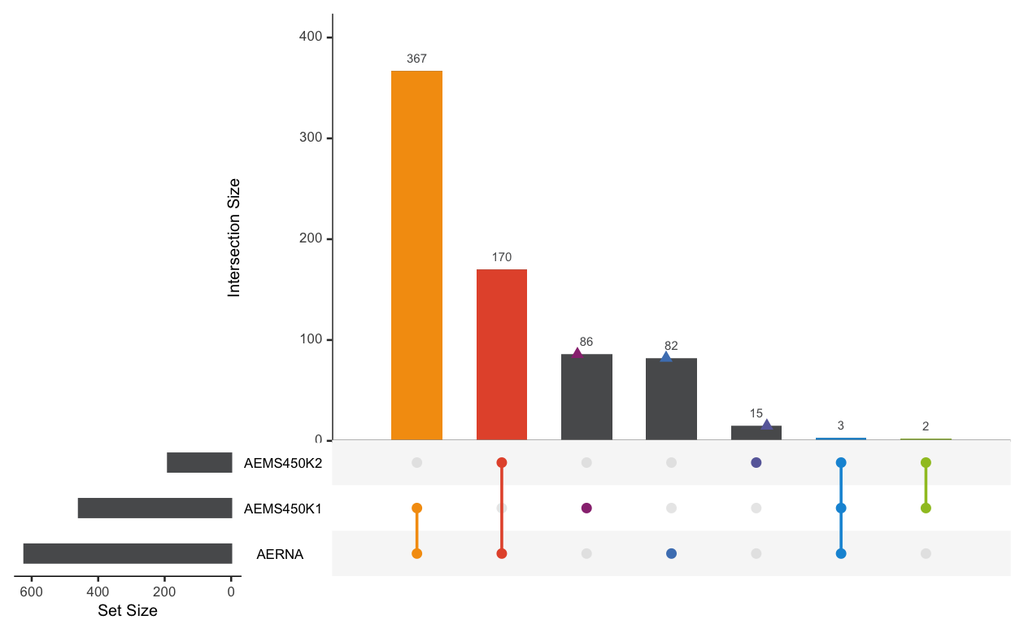

```r
# Reference: https://cran.r-project.org/web/packages/UpSetR/vignettes/attribute.plots.html
library(UpSetR)

upsetSamples(AE_MultiAssay, main.bar.color = "#595A5C", sets.bar.color = "#595A5C",
             queries = list(list(query = intersects, params = list("AEMS450K1", "AERNA"), color = "#F59D10", active = TRUE),
                            list(query = intersects, params = list("AEMS450K2", "AERNA"), color = "#E55738", active = TRUE),
                            list(query = intersects, params = list("AEMS450K1"), color = "#9A3480", active = FALSE),
                            list(query = intersects, params = list("AEMS450K2"), color = "#686AA9", active = FALSE),
                            list(query = intersects, params = list("AERNA"), color = "#4C81BF", active = FALSE),
                            list(query = intersects, params = list("AEMS450K1", "AEMS450K2", "AERNA"),
                                 color = "#1396D8", active = TRUE),
                            list(query = intersects, params = list("AEMS450K1", "AEMS450K2"),
                                 color = "#9FC228", active = TRUE)))
```

#### 4.3.3.6 Baseline Table

```r
cat("====================================================================================================\n")
cat("SELECTION THE SHIZZLE\n")
```

```
SELECTION THE SHIZZLE
```

```r
cat("- sanity checking PRIOR to selection")
```

```
- sanity checking PRIOR to selection
```

```r
library(data.table)
ae.gender <- ifelse(AE_MultiAssay$Gender == 0, "Female", "Male")
ae.hospital <- ifelse(AE_MultiAssay$Hospital == 1, "Antonius", "UMCU")
table(ae.gender, ae.hospital, dnn = c("Sex", "Hospital"))
```

```
      Hospital
Sex    UMCU
  Male  725
```

```r
ae.gender <- ifelse(AE_MultiAssay$Gender == 0, "Female", "Male")
table(ae.gender, AE_MultiAssay$Artery_summary, dnn = c("Sex", "Artery"))
```

```
      Artery
Sex    No artery known (yet), no surgery (patient ill, died, exited study), re-numbered to AAA carotid (left & right)
  Male                                                                                       0                    723
      Artery
Sex    femoral/iliac (left, right or both sides) other carotid arteries (common, external)
  Male                                         0                                         2
      Artery
Sex    carotid bypass and injury (left, right or both sides) aneurysmata (carotid & femoral) aorta
  Male                                                     0                               0     0
      Artery
Sex    other arteries (renal, popliteal, vertebral) femoral bypass, angioseal and injury (left, right or both sides)
  Male                                            0                                                                0
```

```r
# table(ae.gender, AE_MultiAssay$informedconsent, dnn = c("Sex", "IC"))

rm(ae.gender, ae.hospital)

# I change numeric and factors manually because, well, I wouldn't know how to fix it otherwise
# to have this 'tibble' work with 'tableone'... :-)

AE_MultiAssay$Age <- as.numeric(AE_MultiAssay$Age)
AE_MultiAssay$diastoli <- as.numeric(AE_MultiAssay$diastoli)
AE_MultiAssay$systolic <- as.numeric(AE_MultiAssay$systolic)
AE_MultiAssay$GFR_MDRD <- as.numeric(AE_MultiAssay$GFR_MDRD)
AE_MultiAssay$BMI <- as.numeric(AE_MultiAssay$BMI)

require(labelled)
AE_MultiAssay$Gender <- to_factor(AE_MultiAssay$Gender)
AE_MultiAssay$Hospital <- to_factor(AE_MultiAssay$Hospital)
AE_MultiAssay$KDOQI <- to_factor(AE_MultiAssay$KDOQI)
AE_MultiAssay$BMI_WHO <- to_factor(AE_MultiAssay$BMI_WHO)
AE_MultiAssay$DiabetesStatus <- to_factor(AE_MultiAssay$DiabetesStatus)
AE_MultiAssay$SmokerStatus <- to_factor(AE_MultiAssay$SmokerStatus)
AE_MultiAssay$Hypertension.selfreport <- to_factor(AE_MultiAssay$Hypertension.selfreport)
AE_MultiAssay$Hypertension.selfreportdrug <- to_factor(AE_MultiAssay$Hypertension.selfreportdrug)
AE_MultiAssay$Hypertension.composite <- to_factor(AE_MultiAssay$Hypertension.composite)
AE_MultiAssay$Hypertension.drugs <- to_factor(AE_MultiAssay$Hypertension.drugs)
AE_MultiAssay$Med.anticoagulants <- to_factor(AE_MultiAssay$Med.anticoagulants)
AE_MultiAssay$Med.all.antiplatelet <- to_factor(AE_MultiAssay$Med.all.antiplatelet)
AE_MultiAssay$Med.Statin.LLD <- to_factor(AE_MultiAssay$Med.Statin.LLD)

AE_MultiAssay$Symptoms.5G <- to_factor(AE_MultiAssay$Symptoms.5G)
AE_MultiAssay$AsymptSympt <- to_factor(AE_MultiAssay$AsymptSympt)

AE_MultiAssay$restenos <- to_factor(AE_MultiAssay$restenos)
AE_MultiAssay$EP_composite <- to_factor(AE_MultiAssay$EP_composite)
AE_MultiAssay$OverallPlaquePhenotype <- to_factor(AE_MultiAssay$OverallPlaquePhenotype)
AE_MultiAssay$Plaque_Vulnerability_Index <- to_factor(AE_MultiAssay$Plaque_Vulnerability_Index)
AE_MultiAssay$informedconsent <- to_factor(AE_MultiAssay$informedconsent)
AE_MultiAssay$Artery_summary <- to_factor(AE_MultiAssay$Artery_summary)


# We also need to fix some variables

attach(as.data.frame(colData(AE_MultiAssay)))
colData(AE_MultiAssay)$KDOQI[KDOQI == "No data available/missing"] <- NA
colData(AE_MultiAssay)$BMI_WHO[BMI_WHO == "No data available/missing"] <- NA
colData(AE_MultiAssay)$SmokerStatus[SmokerStatus == "no data available/missing"] <- NA
colData(AE_MultiAssay)$Hypertension.selfreport[Hypertension.selfreport == "No data available/missing"] <- NA
colData(AE_MultiAssay)$Hypertension.selfreportdrug[Hypertension.selfreportdrug == "No data available/missing"] <- NA
colData(AE_MultiAssay)$Hypertension.composite[Hypertension.composite == "No data available/missing"] <- NA
colData(AE_MultiAssay)$Hypertension.drugs[Hypertension.drugs == "No data available/missing"] <- NA
colData(AE_MultiAssay)$Med.anticoagulants[Med.anticoagulants == "No data available/missing"] <- NA
colData(AE_MultiAssay)$Med.all.antiplatelet[Med.all.antiplatelet == "No data available/missing"] <- NA
colData(AE_MultiAssay)$Med.Statin.LLD[Med.Statin.LLD == "No data available/missing"] <- NA
colData(AE_MultiAssay)$EP_composite[EP_composite == "No data available."] <- NA

gdata::drop.levels(colData(AE_MultiAssay))
```

```
DataFrame with 725 rows and 32 columns
     STUDY_NUMBER        UPID                                             informedconsent                 Hospital
        <numeric> <character>                                                    <factor>                 <factor>
7               7   UPID01636                                                         yes St. Antonius, Nieuwegein
9               9   UPID00918                                                         yes St. Antonius, Nieuwegein
12             12   UPID00169                                                         yes St. Antonius, Nieuwegein
13             13   UPID00678                                                         yes St. Antonius, Nieuwegein
15             15   UPID01701                                                         yes St. Antonius, Nieuwegein
...           ...         ...                                                         ...                      ...
3766         3766   UPID03838 yes                                                                      UMC Utrecht
3836         3836   UPID03936 yes                                                                      UMC Utrecht
4184         4184   UPID04215 yes                                                                      UMC Utrecht
4185         4185   UPID04216 yes                                                                      UMC Utrecht
4197         4197   UPID04243 yes, health treatment when possible, no commercial business              UMC Utrecht
             Artery_summary       Age   Gender  TC_final LDL_final HDL_final  TG_final  systolic  diastoli  GFR_MDRD       BMI
```

[output cut: 64 more lines]

```r
detach(as.data.frame(colData(AE_MultiAssay)))

AE_MultiAssay.CEA <- subset(AE_MultiAssay,
                    (AE_MultiAssay$Artery_summary == "carotid (left & right)" | AE_MultiAssay$Artery_summary == "other carotid arteries (common, external)") & # we only want carotids
                       AE_MultiAssay$informedconsent != "missing" & # we are really strict in selecting based on 'informed consent'!
                       AE_MultiAssay$informedconsent != "no, died" &
                       AE_MultiAssay$informedconsent != "yes, no tissue, no commerical business" &
                       AE_MultiAssay$informedconsent != "yes, no tissue, no questionnaires, no medical info, no commercial business" &
                       AE_MultiAssay$informedconsent != "yes, no tissue, no questionnaires, no health treatment, no commerical business" &
                       AE_MultiAssay$informedconsent != "yes, no tissue, no questionnaires, no health treatment, no medical info, no commercial business" &
                       AE_MultiAssay$informedconsent != "yes, no tissue, no health treatment" &
                       AE_MultiAssay$informedconsent != "yes, no tissue, no questionnaires" &
                       AE_MultiAssay$informedconsent != "yes, no tissue, health treatment when possible" &
                       AE_MultiAssay$informedconsent != "yes, no tissue" &
                       AE_MultiAssay$informedconsent != "yes, no tissue, no questionnaires, no health treatment, no medical info" &
                       AE_MultiAssay$informedconsent != "yes, no tissue, no questionnaires, no health treatment, no commercial business" &
                       AE_MultiAssay$informedconsent != "no, doesn't want to" &
                       AE_MultiAssay$informedconsent != "no, unable to sign" &
                       AE_MultiAssay$informedconsent != "no, no reaction" &
                       AE_MultiAssay$informedconsent != "no, lost" &
                       AE_MultiAssay$informedconsent != "no, too old" &
                       AE_MultiAssay$informedconsent != "yes, no medical info, health treatment when possible" &
                       AE_MultiAssay$informedconsent != "no (never asked for IC because there was no tissue)" &
                       AE_MultiAssay$informedconsent != "no, endpoint" &
                       AE_MultiAssay$informedconsent != "nooit geincludeerd")
# AE_MultiAssay.CEA[1:10, 1:10]
dim(AE_MultiAssay.CEA)
```

[output not shown]

```r
# AE_MultiAssay.CEA
```

```r
cat("===========================================================================================\n")
cat("CREATE BASELINE TABLE\n")
```

```
CREATE BASELINE TABLE
```

```r
# Baseline table variables

basetable_vars = c("Hospital", "ORyear",
                   "Age", "Gender",
                   "TC_final", "LDL_final", "HDL_final", "TG_final",
                   "systolic", "diastoli", "GFR_MDRD", "BMI",
                   "KDOQI", "BMI_WHO",
                   "SmokerStatus",
                   "DiabetesStatus",
                   "Hypertension.selfreport", "Hypertension.selfreportdrug", "Hypertension.composite", "Hypertension.drugs",
                   "Med.anticoagulants", "Med.all.antiplatelet", "Med.Statin.LLD",
                   "Stroke_Dx", "sympt", "Symptoms.5G", "AsymptSympt", "AsymptSympt2G",
                   "restenos", "stenose",
                   "CAD_history", "PAOD", "Peripheral.interv",
                   "EP_composite", "EP_composite_time", "EP_major", "EP_major_time",
                   "MAC_rankNorm", "SMC_rankNorm", "Macrophages.bin", "SMC.bin",
                   "Neutrophils_rankNorm", "MastCells_rankNorm",
                   "IPH.bin", "VesselDensity_rankNorm",
                   "Calc.bin", "Collagen.bin",
                   "Fat.bin_10", "Fat.bin_40", "OverallPlaquePhenotype", "Plaque_Vulnerability_Index")

basetable_bin = c("Gender",
                  "KDOQI", "BMI_WHO",
                  "SmokerStatus",
                  "DiabetesStatus",
                  "Hypertension.selfreport", "Hypertension.selfreportdrug", "Hypertension.composite", "Hypertension.drugs",
                  "Med.anticoagulants", "Med.all.antiplatelet", "Med.Statin.LLD",
                  "Stroke_Dx", "sympt", "Symptoms.5G", "AsymptSympt", "AsymptSympt2G",
                  "restenos", "stenose",
                  "CAD_history", "PAOD", "Peripheral.interv",
                  "EP_composite", "Macrophages.bin", "SMC.bin",
                  "IPH.bin",
                  "Calc.bin", "Collagen.bin",
                  "Fat.bin_10", "Fat.bin_40", "OverallPlaquePhenotype", "Plaque_Vulnerability_Index")

# basetable_bin

basetable_con = basetable_vars[!basetable_vars %in% basetable_bin]
# basetable_con
```

#### 4.3.3.7 Athero-Express Omics Studies: baseline characteristics

Showing the baseline table of the whole Athero-Express Biobank.

```r
# Create baseline tables
# http://rstudio-pubs-static.s3.amazonaws.com/13321_da314633db924dc78986a850813a50d5.html
AE_MultiAssay.CEA.tableOne = print(CreateTableOne(vars = basetable_vars,
                                                  # factorVars = basetable_bin,
                                                  strata = "AsymptSympt",
                                                  data = as.data.frame(colData(AE_MultiAssay.CEA)), includeNA = TRUE),
                                   nonnormal = c(), missing = TRUE,
                                   quote = FALSE, noSpaces = FALSE, showAllLevels = TRUE, explain = TRUE,
                                   format = "pf",
                                   contDigits = 3)[,1:7]
```

```
The data frame does not have: ORyear Stroke_Dx sympt AsymptSympt2G stenose CAD_history PAOD Peripheral.interv EP_composite_time EP_major EP_major_time MAC_rankNorm SMC_rankNorm Macrophages.bin SMC.bin Neutrophils_rankNorm MastCells_rankNorm IPH.bin VesselDensity_rankNorm Calc.bin Collagen.bin Fat.bi…
```

```
                                      Stratified by AsymptSympt
                                       level                         Asymptomatic     Ocular and others Symptomatic      p
  n                                                                       92              152               480
  Hospital % (freq)                    St. Antonius, Nieuwegein         57.6 (53)        57.2 ( 87)        55.8 (268)     0.923
                                       UMC Utrecht                      42.4 (39)        42.8 ( 65)        44.2 (212)
  Age (mean (SD))                                                     66.065 (9.210)   67.730 (8.325)    68.787 (9.017)   0.021
  Gender % (freq)                      female                           20.7 (19)        31.6 ( 48)        25.0 (120)     0.130
                                       male                             79.3 (73)        68.4 (104)        75.0 (360)
  TC_final (mean (SD))                                                 4.521 (1.191)    4.790 (1.310)     4.698 (1.254)   0.390
  LDL_final (mean (SD))                                                2.687 (1.003)    2.935 (1.100)     2.801 (1.044)   0.342
  HDL_final (mean (SD))                                                1.138 (0.350)    1.181 (0.431)     1.144 (0.362)   0.682
  TG_final (mean (SD))                                                 1.679 (0.856)    1.543 (0.727)     1.587 (0.961)   0.640
  systolic (mean (SD))                                               153.184 (22.759) 152.202 (24.990)  156.062 (25.596)  0.256
  diastoli (mean (SD))                                                80.829 (13.697)  81.620 (13.547)   82.938 (13.456)  0.347
  GFR_MDRD (mean (SD))                                                72.496 (19.864)  70.525 (20.446)   74.052 (20.479)  0.180
  BMI (mean (SD))                                                     26.871 (3.927)   26.859 (3.930)    26.371 (3.794)   0.278
  KDOQI % (freq)                       No data available/missing         0.0 ( 0)         0.0 (  0)         0.0 (  0)       NaN
                                       Normal kidney function           17.4 (16)        15.1 ( 23)        19.6 ( 94)
                                       CKD 2 (Mild)                     54.3 (50)        51.3 ( 78)        54.4 (261)
                                       CKD 3 (Moderate)                 26.1 (24)        28.3 ( 43)        21.7 (104)
                                       CKD 4 (Severe)                    0.0 ( 0)         2.0 (  3)         1.2 (  6)
                                       CKD 5 (Failure)                   0.0 ( 0)         0.0 (  0)         0.0 (  0)
                                       <NA>                              2.2 ( 2)         3.3 (  5)         3.1 ( 15)
  BMI_WHO % (freq)                     No data available/missing         0.0 ( 0)         0.0 (  0)         0.0 (  0)       NaN
                                       Underweight                       2.2 ( 2)         0.7 (  1)         1.2 (  6)
                                       Normal                           31.5 (29)        32.2 ( 49)        35.8 (172)
                                       Overweight                       47.8 (44)        46.7 ( 71)        44.2 (212)
                                       Obese                            15.2 (14)        17.8 ( 27)        13.1 ( 63)
                                       <NA>                              3.3 ( 3)         2.6 (  4)         5.6 ( 27)
  SmokerStatus % (freq)                Current smoker                   30.4 (28)        42.8 ( 65)        35.2 (169)     0.170
                                       Ex-smoker                        47.8 (44)        44.7 ( 68)        43.5 (209)
                                       Never smoked                     16.3 (15)        11.2 ( 17)        16.5 ( 79)
                                       <NA>                              5.4 ( 5)         1.3 (  2)         4.8 ( 23)
  DiabetesStatus % (freq)              Control (no Diabetes Dx/Med)     77.2 (71)        77.6 (118)        78.3 (376)     0.961
                                       Diabetes                         22.8 (21)        22.4 ( 34)        21.7 (104)
  Hypertension.selfreport % (freq)     No data available/missing         0.0 ( 0)         0.0 (  0)         0.0 (  0)       NaN
                                       no                               21.7 (20)        32.2 ( 49)        24.8 (119)
                                       yes                              75.0 (69)        65.8 (100)        73.5 (353)
                                       <NA>                              3.3 ( 3)         2.0 (  3)         1.7 (  8)
  Hypertension.selfreportdrug % (freq) No data available/missing         0.0 ( 0)         0.0 (  0)         0.0 (  0)       NaN
```

[output cut: 124 more lines]

[output not shown]

We can also save this for future reference.

```r
# Write basetable
require(openxlsx)

write.xlsx(file = paste0(BASELINE_loc, "/",Today,".",PROJECTNAME,".AE_MultiAssay.BaselineTable.xlsx"),
           AE_MultiAssay.CEA.tableOne,
           row.names = TRUE,
           col.names = TRUE,
           sheetName = "AE_MultiAssay_Baseline")
```

# 5 MultiAssay Analysis

Let’s extract the data we need.

We will run two models:

- Model 1: [gene-expression] ~ age + gender + Hospital
- Model 2: [gene-expression] ~ age + gender + hospital + BMI + GFR_MDRD + hypertension + diabetes + lipid-lowering drugs

```r
AE_MultiAssay.CEA
```

```
A MultiAssayExperiment object of 3 listed
 experiments with user-defined names and respective classes.
 Containing an ExperimentList class object of length 3:
 [1] AEMS450K1: SummarizedExperiment with 276373 rows and 458 columns
 [2] AEMS450K2: SummarizedExperiment with 276450 rows and 190 columns
 [3] AERNA: RangedSummarizedExperiment with 53197 rows and 622 columns
Features:
 experiments() - obtain the ExperimentList instance
 colData() - the primary/phenotype DFrame
 sampleMap() - the sample availability DFrame
 `$`, `[`, `[[` - extract colData columns, subset, or experiment
 *Format() - convert into a long or wide DFrame
 assays() - convert ExperimentList to a SimpleList of matrices
```

```r
bulkRNA_rowRanges_sub <- subset(bulkRNA_rowRanges, symbol == "IRAK4" | symbol == "PUS7L" | symbol == "CDKN2B-AS1" | symbol == "CDKN2A" | symbol == "CDKN2B")

bulkRNA_rowRanges_sub
```

```
GRanges object with 5 ranges and 3 metadata columns:
                  seqnames            ranges strand |      feature_id      symbol GENEBIOTYPE_EnsDb86
                     <Rle>         <IRanges>  <Rle> |     <character> <character>         <character>
  ENSG00000198001       12 44152747-44183346      + | ENSG00000198001       IRAK4      protein_coding
  ENSG00000129317       12 44122410-44152620      - | ENSG00000129317       PUS7L      protein_coding
  ENSG00000147889       09 21967751-21995300      - | ENSG00000147889      CDKN2A      protein_coding
  ENSG00000147883       09 22002902-22009362      - | ENSG00000147883      CDKN2B      protein_coding
  ENSG00000240498       09 21994777-22121096      + | ENSG00000240498  CDKN2B-AS1           antisense
  -------
  seqinfo: 124 sequences from an unspecified genome; no seqlengths
```

```r
AE_MultiAssay.CEA.sub <- AE_MultiAssay.CEA[c("ENSG00000198001", "ENSG00000129317", "ENSG00000147889", "ENSG00000147883", "ENSG00000240498", "cg20461126"), , ]

AE_MultiAssay.CEA.sub
```

```
A MultiAssayExperiment object of 3 listed
 experiments with user-defined names and respective classes.
 Containing an ExperimentList class object of length 3:
 [1] AEMS450K1: SummarizedExperiment with 1 rows and 458 columns
 [2] AEMS450K2: SummarizedExperiment with 1 rows and 190 columns
 [3] AERNA: RangedSummarizedExperiment with 5 rows and 622 columns
Features:
 experiments() - obtain the ExperimentList instance
 colData() - the primary/phenotype DFrame
 sampleMap() - the sample availability DFrame
 `$`, `[`, `[[` - extract colData columns, subset, or experiment
 *Format() - convert into a long or wide DFrame
 assays() - convert ExperimentList to a SimpleList of matrices
```

Please note that we work with EnsmeblIDs:

```r
wide_AE_MultiAssay <- wideFormat(AE_MultiAssay.CEA.sub,
                                 colDataCols = c("Age", "Gender", "Hospital",
                                                 "BMI", "GFR_MDRD",
                                                 "Hypertension.composite", "DiabetesStatus", "Med.Statin.LLD"))
# wide_AE_MultiAssay
dim(wide_AE_MultiAssay)
```

```
[1] 725  16
```

```r
table(wide_AE_MultiAssay$Gender, wide_AE_MultiAssay$Hospital)
```

```
         St. Antonius, Nieuwegein UMC Utrecht
  female                      116          72
  male                        292         245
```

#### 5.0.0.1 AEMS450K1 vs. AERNA

```r
model1a = "AERNA_ENSG00000198001 ~ AEMS450K1_cg20461126 + Age + Gender + Hospital"
model1b = "AERNA_ENSG00000129317 ~ AEMS450K1_cg20461126 + Age + Gender + Hospital"
model1c = "AERNA_ENSG00000147889 ~ AEMS450K1_cg20461126 + Age + Gender + Hospital"
model1d = "AERNA_ENSG00000147883 ~ AEMS450K1_cg20461126 + Age + Gender + Hospital"
model1e = "AERNA_ENSG00000240498 ~ AEMS450K1_cg20461126 + Age + Gender + Hospital"

irak4_lm <- lm(as.formula(model1a), data = wide_AE_MultiAssay)
pus7l_lm <- lm(as.formula(model1b), data = wide_AE_MultiAssay)
cdkn2a_lm <- lm(as.formula(model1c), data = wide_AE_MultiAssay)
cdkn2b_lm <- lm(as.formula(model1d), data = wide_AE_MultiAssay)
cdkn2bas1_lm <- lm(as.formula(model1e), data = wide_AE_MultiAssay)

summary(irak4_lm)
```

```
Call:
lm(formula = as.formula(model1a), data = wide_AE_MultiAssay)

Residuals:
    Min      1Q  Median      3Q     Max
-29.282 -15.296  -7.715   5.165 301.103

Coefficients:
                     Estimate Std. Error t value Pr(>|t|)
(Intercept)          47.17155   19.96922   2.362  0.01869 *
AEMS450K1_cg20461126  4.96170    3.78737   1.310  0.19100
Age                  -0.09086    0.16955  -0.536  0.59237
Gendermale           -2.11577    3.35266  -0.631  0.52839
HospitalUMC Utrecht  -8.47257    3.11651  -2.719  0.00687 **
---
Signif. codes:  0 '***' 0.001 '**' 0.01 '*' 0.05 '.' 0.1 ' ' 1

Residual standard error: 28.86 on 365 degrees of freedom
  (355 observations deleted due to missingness)
Multiple R-squared:  0.0265,    Adjusted R-squared:  0.01584
F-statistic: 2.484 on 4 and 365 DF,  p-value: 0.04336
```

```r
summary(pus7l_lm)
```

```
Call:
lm(formula = as.formula(model1b), data = wide_AE_MultiAssay)

Residuals:
   Min     1Q Median     3Q    Max
-5.575 -3.571 -2.059  0.788 82.859

Coefficients:
                      Estimate Std. Error t value Pr(>|t|)
(Intercept)           1.070121   5.423283   0.197   0.8437
AEMS450K1_cg20461126 -0.987893   1.028581  -0.960   0.3375
Age                  -0.003472   0.046048  -0.075   0.9399
Gendermale           -1.332345   0.910522  -1.463   0.1443
HospitalUMC Utrecht  -1.681827   0.846387  -1.987   0.0477 *
---
Signif. codes:  0 '***' 0.001 '**' 0.01 '*' 0.05 '.' 0.1 ' ' 1

Residual standard error: 7.839 on 365 degrees of freedom
  (355 observations deleted due to missingness)
Multiple R-squared:  0.02222,   Adjusted R-squared:  0.01151
F-statistic: 2.074 on 4 and 365 DF,  p-value: 0.08369
```

```r
summary(cdkn2bas1_lm)
```

```
Call:
lm(formula = as.formula(model1e), data = wide_AE_MultiAssay)

Residuals:
   Min     1Q Median     3Q    Max
-5.701 -3.952 -2.367  0.550 40.671

Coefficients:
                      Estimate Std. Error t value Pr(>|t|)
(Intercept)           6.736171   4.804264   1.402   0.1617
AEMS450K1_cg20461126  0.187639   0.911178   0.206   0.8370
Age                  -0.009937   0.040792  -0.244   0.8077
Gendermale           -1.213184   0.806594  -1.504   0.1334
HospitalUMC Utrecht  -1.463591   0.749780  -1.952   0.0517 .
---
Signif. codes:  0 '***' 0.001 '**' 0.01 '*' 0.05 '.' 0.1 ' ' 1

Residual standard error: 6.944 on 365 degrees of freedom
  (355 observations deleted due to missingness)
Multiple R-squared:  0.01899,   Adjusted R-squared:  0.008238
F-statistic: 1.766 on 4 and 365 DF,  p-value: 0.135
```

```r
summary(cdkn2a_lm)
```

```
Call:
lm(formula = as.formula(model1c), data = wide_AE_MultiAssay)

Residuals:
   Min     1Q Median     3Q    Max
-8.621 -5.886 -3.515  1.398 75.042

Coefficients:
                     Estimate Std. Error t value Pr(>|t|)
(Intercept)           0.25234    7.26679   0.035   0.9723
AEMS450K1_cg20461126 -1.30320    1.37822  -0.946   0.3450
Age                   0.02742    0.06170   0.444   0.6570
Gendermale           -1.47622    1.22003  -1.210   0.2271
HospitalUMC Utrecht  -2.46253    1.13409  -2.171   0.0305 *
---
Signif. codes:  0 '***' 0.001 '**' 0.01 '*' 0.05 '.' 0.1 ' ' 1

Residual standard error: 10.5 on 365 degrees of freedom
  (355 observations deleted due to missingness)
Multiple R-squared:  0.02266,   Adjusted R-squared:  0.01195
F-statistic: 2.116 on 4 and 365 DF,  p-value: 0.07827
```

```r
summary(cdkn2b_lm)
```

```
Call:
lm(formula = as.formula(model1d), data = wide_AE_MultiAssay)

Residuals:
    Min      1Q  Median      3Q     Max
-28.136 -19.367 -11.615   1.666 232.183

Coefficients:
                     Estimate Std. Error t value Pr(>|t|)
(Intercept)          -22.4593    25.4303  -0.883   0.3777
AEMS450K1_cg20461126  -7.9362     4.8231  -1.645   0.1007
Age                    0.1625     0.2159   0.752   0.4523
Gendermale            -2.1338     4.2695  -0.500   0.6175
HospitalUMC Utrecht   -8.0771     3.9688  -2.035   0.0426 *
---
Signif. codes:  0 '***' 0.001 '**' 0.01 '*' 0.05 '.' 0.1 ' ' 1

Residual standard error: 36.76 on 365 degrees of freedom
  (355 observations deleted due to missingness)
Multiple R-squared:  0.023, Adjusted R-squared:  0.01229
F-statistic: 2.148 on 4 and 365 DF,  p-value: 0.07443
```

```r
model2a = "AERNA_ENSG00000198001 ~ AEMS450K1_cg20461126 + Age + Gender + Hospital + BMI + GFR_MDRD + Hypertension.composite + DiabetesStatus + Med.Statin.LLD"
model2b = "AERNA_ENSG00000129317 ~ AEMS450K1_cg20461126 + Age + Gender + Hospital + BMI + GFR_MDRD + Hypertension.composite + DiabetesStatus + Med.Statin.LLD"
model2c = "AERNA_ENSG00000147889 ~ AEMS450K1_cg20461126 + Age + Gender + Hospital + BMI + GFR_MDRD + Hypertension.composite + DiabetesStatus + Med.Statin.LLD"
model2d = "AERNA_ENSG00000147883 ~ AEMS450K1_cg20461126 + Age + Gender + Hospital + BMI + GFR_MDRD + Hypertension.composite + DiabetesStatus + Med.Statin.LLD"
model2e = "AERNA_ENSG00000240498 ~ AEMS450K1_cg20461126 + Age + Gender + Hospital + BMI + GFR_MDRD + Hypertension.composite + DiabetesStatus + Med.Statin.LLD"

irak4_lm_add <- lm(as.formula(model2a), data = wide_AE_MultiAssay)
pus7l_lm_add <- lm(as.formula(model2b), data = wide_AE_MultiAssay)
cdkn2a_lm_add <- lm(as.formula(model2c), data = wide_AE_MultiAssay)
cdkn2b_lm_add <- lm(as.formula(model2d), data = wide_AE_MultiAssay)
cdkn2bas1_lm_add <- lm(as.formula(model2e), data = wide_AE_MultiAssay)

summary(irak4_lm_add)
```

```
Call:
lm(formula = as.formula(model2a), data = wide_AE_MultiAssay)

Residuals:
    Min      1Q  Median      3Q     Max
-30.047 -14.268  -6.722   4.172 300.939

Coefficients:
                          Estimate Std. Error t value Pr(>|t|)
(Intercept)               43.28829   28.38023   1.525  0.12813
AEMS450K1_cg20461126       5.33492    3.98991   1.337  0.18209
Age                       -0.11447    0.20325  -0.563  0.57366
Gendermale                -0.15373    3.57092  -0.043  0.96569
HospitalUMC Utrecht       -9.25737    3.31690  -2.791  0.00556 **
BMI                        0.43028    0.43271   0.994  0.32075
GFR_MDRD                  -0.08305    0.08671  -0.958  0.33887
Hypertension.compositeyes -0.18136    4.88767  -0.037  0.97042
DiabetesStatusDiabetes    -5.21355    3.93114  -1.326  0.18567
Med.Statin.LLDyes          2.53076    4.04795   0.625  0.53227
---
Signif. codes:  0 '***' 0.001 '**' 0.01 '*' 0.05 '.' 0.1 ' ' 1

Residual standard error: 29.52 on 336 degrees of freedom
  (379 observations deleted due to missingness)
Multiple R-squared:  0.03745,   Adjusted R-squared:  0.01167
F-statistic: 1.452 on 9 and 336 DF,  p-value: 0.1646
```

```r
summary(pus7l_lm_add)
```

```
Call:
lm(formula = as.formula(model2b), data = wide_AE_MultiAssay)

Residuals:
   Min     1Q Median     3Q    Max
-6.239 -3.313 -1.946  0.861 48.345

Coefficients:
                           Estimate Std. Error t value Pr(>|t|)
(Intercept)               -4.327588   6.425892  -0.673   0.5011
AEMS450K1_cg20461126      -0.893132   0.903401  -0.989   0.3236
Age                        0.011285   0.046020   0.245   0.8064
Gendermale                -0.473839   0.808532  -0.586   0.5582
HospitalUMC Utrecht       -1.817462   0.751016  -2.420   0.0161 *
BMI                        0.116633   0.097974   1.190   0.2347
GFR_MDRD                  -0.001687   0.019632  -0.086   0.9316
Hypertension.compositeyes -0.056971   1.106674  -0.051   0.9590
DiabetesStatusDiabetes    -0.578763   0.890095  -0.650   0.5160
Med.Statin.LLDyes          1.703612   0.916542   1.859   0.0639 .
---
Signif. codes:  0 '***' 0.001 '**' 0.01 '*' 0.05 '.' 0.1 ' ' 1

Residual standard error: 6.684 on 336 degrees of freedom
  (379 observations deleted due to missingness)
Multiple R-squared:  0.03551,   Adjusted R-squared:  0.009679
F-statistic: 1.375 on 9 and 336 DF,  p-value: 0.1982
```

```r
summary(cdkn2bas1_lm_add)
```

```
Call:
lm(formula = as.formula(model2e), data = wide_AE_MultiAssay)

Residuals:
   Min     1Q Median     3Q    Max
-6.488 -3.696 -2.179  0.648 40.218

Coefficients:
                          Estimate Std. Error t value Pr(>|t|)
(Intercept)                4.64886    6.70134   0.694   0.4883
AEMS450K1_cg20461126       0.25066    0.94212   0.266   0.7904
Age                       -0.01055    0.04799  -0.220   0.8261
Gendermale                -0.75711    0.84319  -0.898   0.3699
HospitalUMC Utrecht       -1.70845    0.78321  -2.181   0.0299 *
BMI                        0.10215    0.10217   1.000   0.3181
GFR_MDRD                  -0.01782    0.02047  -0.870   0.3848
Hypertension.compositeyes  0.21543    1.15411   0.187   0.8520
DiabetesStatusDiabetes    -1.12635    0.92825  -1.213   0.2258
Med.Statin.LLDyes          1.06730    0.95583   1.117   0.2650
---
Signif. codes:  0 '***' 0.001 '**' 0.01 '*' 0.05 '.' 0.1 ' ' 1

Residual standard error: 6.971 on 336 degrees of freedom
  (379 observations deleted due to missingness)
Multiple R-squared:  0.03039,   Adjusted R-squared:  0.004416
F-statistic:  1.17 on 9 and 336 DF,  p-value: 0.3133
```

```r
summary(cdkn2a_lm_add)
```

```
Call:
lm(formula = as.formula(model2c), data = wide_AE_MultiAssay)

Residuals:
    Min      1Q  Median      3Q     Max
-10.107  -5.603  -3.535   1.465  48.920

Coefficients:
                          Estimate Std. Error t value Pr(>|t|)
(Intercept)               -6.79103    9.58411  -0.709  0.47908
AEMS450K1_cg20461126      -1.15505    1.34741  -0.857  0.39193
Age                        0.04585    0.06864   0.668  0.50459
Gendermale                -0.64628    1.20591  -0.536  0.59236
HospitalUMC Utrecht       -2.92101    1.12013  -2.608  0.00952 **
BMI                        0.18605    0.14613   1.273  0.20382
GFR_MDRD                  -0.01361    0.02928  -0.465  0.64239
Hypertension.compositeyes  0.30605    1.65059   0.185  0.85301
DiabetesStatusDiabetes    -0.47904    1.32756  -0.361  0.71844
Med.Statin.LLDyes          2.38682    1.36701   1.746  0.08172 .
---
Signif. codes:  0 '***' 0.001 '**' 0.01 '*' 0.05 '.' 0.1 ' ' 1

Residual standard error: 9.97 on 336 degrees of freedom
  (379 observations deleted due to missingness)
Multiple R-squared:  0.0377,    Adjusted R-squared:  0.01193
F-statistic: 1.463 on 9 and 336 DF,  p-value: 0.1605
```

```r
summary(cdkn2b_lm_add)
```

```
Call:
lm(formula = as.formula(model2d), data = wide_AE_MultiAssay)

Residuals:
    Min      1Q  Median      3Q     Max
-34.408 -19.220 -11.649   1.985 223.126

Coefficients:
                           Estimate Std. Error t value Pr(>|t|)
(Intercept)               -40.88644   36.19324  -1.130   0.2594
AEMS450K1_cg20461126       -7.99781    5.08832  -1.572   0.1169
Age                         0.22510    0.25920   0.868   0.3858
Gendermale                 -1.28410    4.55398  -0.282   0.7781
HospitalUMC Utrecht        -9.93659    4.23003  -2.349   0.0194 *
BMI                         0.56510    0.55183   1.024   0.3065
GFR_MDRD                   -0.09498    0.11058  -0.859   0.3910
Hypertension.compositeyes   0.92484    6.23324   0.148   0.8821
DiabetesStatusDiabetes      0.25904    5.01338   0.052   0.9588
Med.Statin.LLDyes           7.13747    5.16234   1.383   0.1677
---
Signif. codes:  0 '***' 0.001 '**' 0.01 '*' 0.05 '.' 0.1 ' ' 1

Residual standard error: 37.65 on 336 degrees of freedom
  (379 observations deleted due to missingness)
Multiple R-squared:  0.03773,   Adjusted R-squared:  0.01196
F-statistic: 1.464 on 9 and 336 DF,  p-value: 0.16
```

# 6 Information

## 6.1 Session information

```
Version:     v1.0.3
Last update: 2020-08-06
Written by:  Sander W. van der Laan (s.w.vanderlaan-2[at]umcutrecht.nl).
Description: ELSIE: EvoLutionary Selection In Epigenetics and transcriptomics in the Athero-Express Biobank Study.
Minimum requirements: R version 3.5.2 (2018-12-20) -- 'Eggshell Igloo', macOS Mojave (10.14.2).

Changes log
* v1.0.2 Analysis of target CpG and target genes..
* v1.0.2 Some fixes to the annotations.
* v1.0.1 Updated RNAseq data with Ensemble gene codes. Updated and filtered methylation data. Updated clinical data. General updates to codes.
* v1.0.0 Initial version.
```

## 6.2 Saving environment

Saving RDS of `MultiAssayExperiment`.

```r
# Save as RDS
saveRDS(AE_MultiAssay.CEA, paste0(OUT_loc, "/",Today,".",PROJECTNAME,".AE_MEA.CEA.allClinData.rds"))
```

```r
rm(AEMS450K1.SE.rowData, AEMS450K2.SE.rowData,
   AEMS450K1.SE.assay, AEMS450K2.SE.assay,
   AEMS450K1.SE.metadata, AEMS450K2.SE.metadata,
   aems450k1.MvaluesQCIMPplaqueSE, aems450k2.MvaluesQCIMPplaqueSE,
   aems450k1.MvaluesQCIMPplaqueSECLEAN, aems450k2.MvaluesQCIMPplaqueSECLEAN,
   AEMS450K1.SE, AEMS450K2.SE)

rm(AERNA_UMIcorrSE, AERNA_UMIcorr,
   bulkRNA_counts, bulkRNA_rowRanges, bulkRNA_meta)

rm(AE_MultiAssay)

rm(infobcp,
   hm450.hg19.manifest.180909, hm450.hg19.manifest.naeem, hm450.hg19.manifest.naeem.list, hm450.controls, hm450.manifest.pop.GoNL)

rm(UPID_ZIPcodes)

rm(IlluminaHumanMethylation450kanno.ilmn12.hg19)

rm(AE_MultiAssay, AE_MultiAssay.CEA)

rm(counts, scRNAseqData)
```

```r
save.image(paste0(PROJECT_loc, "/",Today,".",PROJECTNAME,".results.RData"))
```

| <sup>© 1979-2020 Sander W. van der Laan \| s.w.vanderlaan-2[at]umcutrecht.nl \| swvanderlaan.github.io.</sup> |
| --- |

[^1]: Zhou W., Laird P.W. and Shen H., “Comprehensive characterization, annotation and innovative use of Infinium DNA Methylation BeadChip probes.”, [Nucleic Acids Research, Volume 45, Issue 4, 28 February 2017, Page e22](https://doi.org/10.1093/nar/gkw967).
[^2]: Reference: http://waldronlab.io/MultiAssayExperiment/articles/MultiAssayExperiment.html
[^3]: Van Iterson M., Cats D., Hop P., and Heijmans B.T. 2018. “OmicsPrint: Detection of Data Linkage Errors in Multiple Omics Studies.” Edited by Oliver Stegle. [Bioinformatics 34 (12) (June): 2142–2143](https://academic.oup.com/bioinformatics/article/34/12/2142/4840579). DOI:10.1093/bioinformatics/bty062.
[^4]: Reference: http://waldronlab.io/MultiAssayExperiment/articles/MultiAssayExperiment.html
[^5]: Van Iterson M., Cats D., Hop P., and Heijmans B.T. 2018. “OmicsPrint: Detection of Data Linkage Errors in Multiple Omics Studies.” Edited by Oliver Stegle. [Bioinformatics 34 (12) (June): 2142–2143](https://academic.oup.com/bioinformatics/article/34/12/2142/4840579). DOI:10.1093/bioinformatics/bty062.
[^6]: Reference: http://waldronlab.io/MultiAssayExperiment/articles/MultiAssayExperiment.html